# 02_modelFitting_zeroTreeModel_SensEqSpec

## Then, look at the spatial distribution and environmental characteristics of the grouped ecoregions

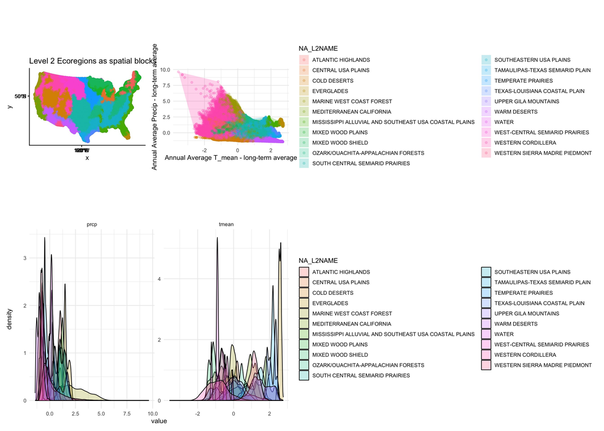

```r
map1 <- ggplot() +
  geom_sf(data=cropped_states,fill='white') +
  geom_sf(data=modDat_1_sf#[modDat_1_sf$NA_L2NAME %in% c("MIXED WOOD PLAINS"),]
          ,
          aes(fill=as.factor(NA_L2NAME)),linewidth=0.5,alpha=0.5) +
  geom_point(data=modDat_1_s#[modDat_1_s$NA_L2NAME %in% c("MIXED WOOD PLAINS"),]
             ,
             alpha=0.5,
             aes(x = x, y = y, color=as.factor(NA_L2NAME)), alpha = .1) +
  #scale_fill_okabeito() +
  #scale_color_okabeito() +
 # theme_default() +
  theme(legend.position = 'none') +
  labs(title = "Level 2 Ecoregions as spatial blocks")
hull <- modDat_1_sf %>%
  ungroup() %>%
  group_by(NA_L2NAME) %>%
  slice(chull(tmean, prcp))

plot1<-ggplot(data=modDat_1_sf,aes(x=tmean,y=prcp)) +
  geom_polygon(data = hull, alpha = 0.25,aes(fill=NA_L2NAME) )+
  geom_point(aes(group=NA_L2NAME,color=NA_L2NAME),alpha=0.25) +
  theme_minimal() + xlab("Annual Average T_mean - long-term average") +
  ylab("Annual Average Precip - long-term average") #+
  #scale_color_okabeito() +
  #scale_fill_okabeito()

plot2<-ggplot(data=modDat_1_sf %>%
                pivot_longer(cols=tmean:prcp),
              aes(x=value,group=name)) +
  # geom_polygon(data = hull, alpha = 0.25,aes(fill=fold) )+
  geom_density(aes(group=NA_L2NAME,fill=NA_L2NAME),alpha=0.25) +
  theme_minimal() +
  facet_wrap(~name,scales='free')

library(patchwork)
(combo <- (map1+plot1)/plot2)
```

```r
rm(modDat_1_sf)
gc()
```

```
##              used   (Mb) gc trigger    (Mb) limit (Mb)   max used    (Mb)
## Ncells   42382853 2263.5   98754648  5274.1         NA   98754648  5274.1
## Vcells 1146717827 8748.8 1799874682 13732.0      65536 1799724533 13730.9
```

## Fit a global model with all of the data

### First, fit a LASSO regression model using the glmnet R package

#### Get rid of transformed predictions and interactions that are correlated

```r
# get first pass of names correlated variables
X_df <- X %>%
  as.data.frame() %>%
  dplyr::select(-'(Intercept)')
corrNames_i <- X_df %>%
  cor()  %>%
   caret::findCorrelation(cutoff = .7, verbose = FALSE, names = TRUE, exact = TRUE)
# remove those names that are untransformed main effects
  # vector of columns to remove
badNames <- corrNames_i[!(corrNames_i %in% prednames)]
while (sum(!(corrNames_i %in% prednames))>0) {
 corrNames_i <-  X_df %>%
    dplyr::select(-badNames) %>%
     cor()  %>%
   caret::findCorrelation(cutoff = .7, verbose = FALSE, names = TRUE, exact = TRUE)
 # update the vector of names to remove
 badNames <- unique(c(badNames, corrNames_i[!(corrNames_i %in% prednames)]))
}
## see if there are any correlated variables left (would be all main effects at this point)
# if there are, step through and remove the variable that each is most correlated with
if (length(corrNames_i)>1) {
  for (i in 1:length(corrNames_i)) {
    X_i <- X_df %>%
      dplyr::select(-badNames)
    if (corrNames_i[i] %in% names(X_i)) {
    corMat_i <- cor(x = X_i[corrNames_i[i]], y = X_i %>% dplyr::select(-corrNames_i[i]))
    badNames_i <- colnames(corMat_i)[abs(corMat_i)>=.7]
    # if there are any predictors in the 'badNames_i', remove them from this list
    if (length(badNames_i) > 0 & sum(c(badNames_i %in% prednames))>0) {
        badNames_i <- badNames_i[!(badNames_i %in% prednames)]
    }
    badNames <- unique(c(badNames, badNames_i))
    }
  }
}
## update the X matrix to exclude these correlated variables
X <- X[,!(colnames(X) %in% badNames)]

rm(X_df)
```

#### Run the global LASSO model

```r
if (run == TRUE) {
  # set up custom folds
    # get the ecoregions for training lambda
  train_eco <- modDat_1_s$NA_L2NAME#[train]

  # Fit model -----------------------------------------------
  # specify leave-one-year-out cross-validation
  my_folds <- as.numeric(as.factor(train_eco))

    # set up parallel processing
    # this computer has 16 cores (parallel::detectCores())
    registerDoMC(cores = 8)

    fit <- cv.glmnet(
      x = X[,2:ncol(X)],
      y = y,
      family = "binomial", #quasibeta_family(),
      keep = FALSE,
      alpha = 1,  # 0 == ridge regression, 1 == lasso, 0.5 ~~ elastic net
      lambda = lambdas,
      relax = ifelse(response == "ShrubCover", yes = TRUE, no = FALSE),
      #nlambda = 100,
      type.measure="mse",
      #penalty.factor = pen_facts,
      foldid = my_folds,
      #thresh = thresh,
      standardize = FALSE, ## scales variables prior to the model sequence... coefficients are always returned on the original scale
      parallel = TRUE
    )
    base::saveRDS(fit, paste0("../ModelFitting/models/yesOrNoTrees_globalLASSOmod_binomial_treeCutoff_",treeThreshold,".rds"))


     best_lambda <- fit$lambda.min
  # save the lambda for the most regularized model w/ an MSE that is still 1SE w/in the best lambda model
  lambda_1SE <- fit$lambda.1se
  # save the lambda for the most regularized model w/ an MSE that is still .5SE w/in the best lambda model
  lambda_halfSE <- best_lambda + ((lambda_1SE - best_lambda)/2)

## Now, we need to do stability selection to ensure the coefficients that are being chosen with each lambda are stable

## stability selection for best lambda model
# setup params
p <- ncol(X[,2:ncol(X)]) # of parameters
n <- length(y) # of observations
n_iter <- 100        # number of subsamples
sample_frac <- 0.75  # fraction of data to subsample
lambda_val <- best_lambda    # fixed lambda value (could be chosen via CV)

# Track selection
selection_counts_bestL <- matrix(0, nrow = p, ncol = 1)

for (i in 1:n_iter) {
  # Subsample rows
  sample_idx <- sample(1:n, size = floor(sample_frac * n), replace = FALSE)
  X_sub <- X[sample_idx, ]
  y_sub <- y[sample_idx]

  # Fit Lasso model
  fit_stab_i <- glmnet(x = X_sub[,2:ncol(X_sub)], y = y_sub,
    family = "binomial",
    alpha = 1, lambda = lambda_val, standardize = FALSE)

  # Get non-zero coefficients (excluding intercept)
  select_bestL <- which(as.vector(coef(fit_stab_i))[-1] != 0)
  selection_counts_bestL[select_bestL] <- selection_counts_bestL[select_bestL] + 1
}

# Convert counts to selection probabilities (the probability that a variable is selected over 100 iterations)
selection_prob_bestL <- selection_counts_bestL / n_iter
selection_prob_bestL_df <- data.frame(
  VariableNumber = paste0("X", 1:p),
  VariableName = rownames(coef(fit_stab_i))[2:(p+1)],
  SelectionProb = as.vector(selection_prob_bestL)
)

# get those variables that are selected in ≥70% of subsets (Meinshausen and Bühlmann, 2010)
bestLambda_coef <- selection_prob_bestL_df[selection_prob_bestL_df$SelectionProb>=.7, c("VariableName", "SelectionProb")]

#//////
# stability selection for 1se lambda model
lambda_val <-  lambda_1SE    # fixed lambda value (could be chosen via CV)

# Track selection
selection_counts_1seL <- matrix(0, nrow = p, ncol = 1)

for (i in 1:n_iter) {
  # Subsample rows
  sample_idx <- sample(1:n, size = floor(sample_frac * n), replace = FALSE)
  X_sub <- X[sample_idx, ]
  y_sub <- y[sample_idx]

  # Fit Lasso model
  fit_stab_i <- glmnet(x = X_sub[,2:ncol(X_sub)], y = y_sub,
    family = "binomial",
    alpha = 1, lambda = lambda_val, standardize = FALSE)

  # Get non-zero coefficients (excluding intercept)
  selected_1seL <- which(as.vector(coef(fit_stab_i))[-1] != 0)
  selection_counts_1seL[selected_1seL] <- selection_counts_1seL[selected_1seL] + 1
}

# Convert counts to selection probabilities (the probability that a variable is selected over 100 iterations)
selection_prob_1seL <- selection_counts_1seL / n_iter
selection_prob_1seL_df <- data.frame(
  VariableNumber = paste0("X", 1:p),
  VariableName = rownames(coef(fit_stab_i))[2:(p+1)],
  SelectionProb = as.vector(selection_prob_1seL)
)

# get those variables that are selected in ≥70% of subsets (Meinshausen and Bühlmann, 2010)
seLambda_coef <- selection_prob_1seL_df[selection_prob_1seL_df$SelectionProb>=.7, c("VariableName", "SelectionProb")]

# stability selection for half se lambda model
lambda_val <- lambda_halfSE    # fixed lambda value (could be chosen via CV)

# Track selection
selection_counts_halfseL <- matrix(0, nrow = p, ncol = 1)

for (i in 1:n_iter) {
  # Subsample rows
  sample_idx <- sample(1:n, size = floor(sample_frac * n), replace = FALSE)
  X_sub <- X[sample_idx, ]
  y_sub <- y[sample_idx]

  # Fit Lasso model
  fit_stab_i <- glmnet(x = X_sub[,2:ncol(X_sub)], y = y_sub,
    family = "binomial",
    alpha = 1, lambda = lambda_val, standardize = FALSE)

  # Get non-zero coefficients (excluding intercept)
  selected_halfseL <- which(as.vector(coef(fit_stab_i))[-1] != 0)
  selection_counts_halfseL[selected_halfseL] <- selection_counts_halfseL[selected_halfseL] + 1
}

# Convert counts to selection probabilities (the probability that a variable is selected_halfseL over 100 iterations)
selection_prob_halfseL <- selection_counts_halfseL / n_iter
selection_prob_halfseL_df <- data.frame(
  VariableNumber = paste0("X", 1:p),
  VariableName = rownames(coef(fit_stab_i))[2:(p+1)],
  SelectionProb = as.vector(selection_prob_halfseL)
)

# get those variables that are selected_halfseL_halfseL in ≥70% of subsets (Meinshausen and Bühlmann, 2010)
halfseLambda_coef <- selection_prob_halfseL_df[selection_prob_halfseL_df$SelectionProb>=.7, c("VariableName", "SelectionProb")]

## fit w/ the identified coefficients from the 'best' lambda, but using the glm function
  mat_glmnet_best <- bestLambda_coef$VariableName

  if (length(mat_glmnet_best) == 0) {
    f_glm_bestLambda <- as.formula(paste0(response, "~ 1"))
  } else {
  f_glm_bestLambda <- as.formula(paste0(response, " ~ ", paste0(mat_glmnet_best, collapse = " + ")))
  }

## fit
  fit_glm_bestLambda <- fit_glm_bestLambda_binomial <- glm(formula = f_glm_bestLambda, data = modDat_1_s, family = "binomial")

   ## fit w/ the identified coefficients from the '1se' lambda, but using the glm function
  mat_glmnet_1se <- seLambda_coef$VariableName

  if (length(mat_glmnet_1se) == 0) {
    f_glm_1se <- as.formula(paste0(response, "~ 1"))
  } else {
  f_glm_1se <- as.formula(paste0(response, " ~ ", paste0(mat_glmnet_1se, collapse = " + ")))
  }


  fit_glm_se <- glm(formula = f_glm_1se, data = modDat_1_s, family = "binomial")
  # glm(data = modDat_1_s, formula = f_glm_1se,
  #                   family =  stats::Gamma(link = "log"))

     ## fit w/ the identified coefficients from the '.5se' lambda, but using the glm function
  mat_glmnet_halfse <- halfseLambda_coef$VariableName

  if (length(mat_glmnet_halfse) == 0) {
    f_glm_halfse <- as.formula(paste0(response, "~ 1"))
  } else {
  f_glm_halfse <- as.formula(paste0(response, " ~ ", paste0(mat_glmnet_halfse, collapse = " + ")))
  }

  fit_glm_halfse <- glm(formula = f_glm_halfse, data = modDat_1_s, family = "binomial")

  ## save models
  saveRDS(fit_glm_bestLambda, paste0("./models/yesOrNoTrees_bestLambdaGLM_",treeThreshold,".rds"))
  saveRDS(fit_glm_halfse, paste0("./models/yesOrNoTrees_halfSELambdaGLM_",treeThreshold,".rds"))
  saveRDS(fit_glm_se, paste0("./models/yesOrNoTrees_oneSELambdaGLM_",treeThreshold,".rds"))

  ## save the R environment after running the models
  save(f_glm_halfse, mat_glmnet_halfse, halfseLambda_coef,
              f_glm_1se, mat_glmnet_1se, seLambda_coef,
              f_glm_bestLambda, mat_glmnet_best, bestLambda_coef,
              file = paste0("./models/interimModelFittingObjects_yesOrNoTrees_binomial_",treeThreshold,".rds"))
  } else {
    # read in LASSO object
    fit <- readRDS(paste0("../ModelFitting/models/yesOrNoTrees_globalLASSOmod_binomial_treeCutoff_",treeThreshold,".rds"))

    # read in R objects having to do w/ model fitting
    load(file = paste0("./models/interimModelFittingObjects_yesOrNoTrees_binomial_",treeThreshold,".rds"))

  fit_glm_bestLambda <- readRDS(paste0("./models/yesOrNoTrees_bestLambdaGLM_",treeThreshold,".rds"))
  fit_glm_halfse <- readRDS(paste0("./models/yesOrNoTrees_halfSELambdaGLM_",treeThreshold,".rds"))
  fit_glm_se <- readRDS(paste0("./models/yesOrNoTrees_oneSELambdaGLM_",treeThreshold,".rds"))
  }


  # assess model fit
  # assess.glmnet(fit$fit.preval, #newx = X[,2:293],
  #               newy = y, family = stats::Gamma(link = "log"))
  # save the minimum lambda
  best_lambda <- fit$lambda.min
  # save the lambda for the most regularized model w/ an MSE that is still 1SE w/in the best lambda model
  lambda_1SE <- fit$lambda.1se
  # save the lambda for the most regularized model w/ an MSE that is still .5SE w/in the best lambda model
  lambda_halfSE <- best_lambda + ((lambda_1SE - best_lambda)/2)

  print(fit)
```

```
##
## Call:  cv.glmnet(x = X[, 2:ncol(X)], y = y, lambda = lambdas, type.measure = "mse",      foldid = my_folds, keep = FALSE, parallel = TRUE, relax = ifelse(response ==          "ShrubCover", yes = TRUE, no = FALSE), family = "binomial",      alpha = 1, standardize = FALSE)
##
## Measure: Mean-Squared Error
##
##      Lambda Index Measure      SE Nonzero
## min 0.00007   172  0.2122 0.03119      26
## 1se 0.01367    96  0.2422 0.03548      13
```

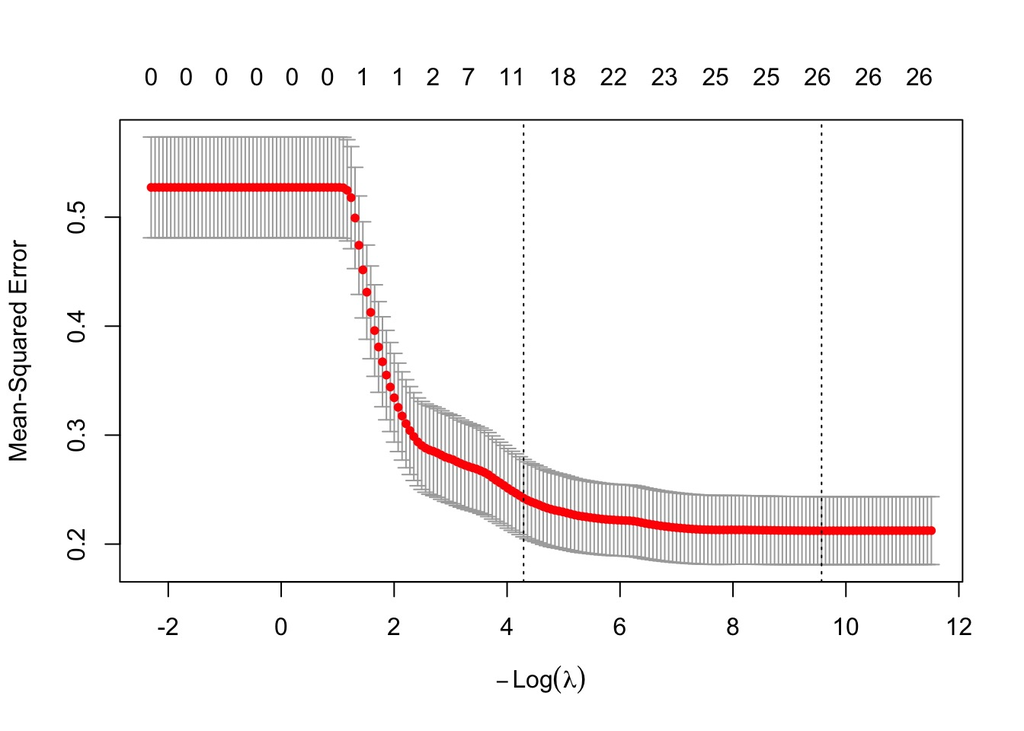

```r
  plot(fit)
```

#### Then, we predict (on the training set) using both of these models (best lambda and 1se lambda) as an itial test

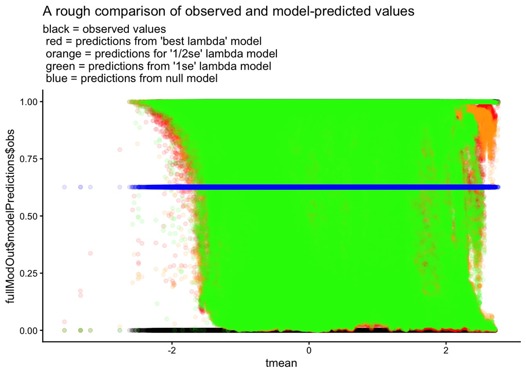

```r
  ## predict on the test data
  # lasso model predictions with the optimal lambda
  optimal_pred <- stats::predict(fit_glm_bestLambda, #newx=X[,2:ncol(X)],
                                 type = "response")
  optimal_pred_1se <-  stats::predict(fit_glm_se, newx=X[,2:ncol(X)], type = "response")
  optimal_pred_halfse <- stats::predict(fit_glm_halfse, newx = X[,2:ncol(X)], type = "response")

    null_fit <- glm(
      formula = y ~ 1, #data = modDat_1_s,
      family = binomial
      )
  null_pred <- predict(null_fit, newdata = as.data.frame(X), type = "response"
                       )

  # save data
  fullModOut <- list(
    "modelObject" = fit,
    "nullModelObject" = null_fit,
    "modelPredictions" = data.frame(#ecoRegion_holdout = rep(test_eco,length(y)),
      obs=y,
                    pred_opt=optimal_pred,
                    pred_opt_se = optimal_pred_1se,
                    pred_opt_halfse = optimal_pred_halfse,
                    pred_null=null_pred#,
                    #pred_nopenalty=nopen_pred
                    ))

ggplot() +
  geom_point(aes(X[,2], fullModOut$modelPredictions$obs), col = "black", alpha = .1) +
  geom_point(aes(X[,2], fullModOut$modelPredictions$pred_opt), col = "red", alpha = .1) + ## predictions w/ the CV model (best lambda)
  geom_point(aes(X[,2], fullModOut$modelPredictions$pred_opt_halfse), col = "orange", alpha = .1) + ## predictions w/ the CV model (.5se lambda)
  geom_point(aes(X[,2], fullModOut$modelPredictions$pred_opt_se), col = "green", alpha = .1) + ## predictions w/ the CV model (1se lambda)
  geom_point(aes(X[,2], fullModOut$modelPredictions$pred_null), col = "blue", alpha = .1) +
  labs(title = "A rough comparison of observed and model-predicted values",
       subtitle = "black = observed values \n red = predictions from 'best lambda' model \n orange = predictions for '1/2se' lambda model \n green = predictions from '1se' lambda model \n blue = predictions from null model") +
  xlab(colnames(X)[2])
```

```r
  #ylim(c(0,200))
```

```r
# the coefficient matrix from the 'best model' -- find and print those coefficients that aren't 0 in a table
coef_glm_bestLambda <- coef(fit_glm_bestLambda) %>%
  data.frame()
coef_glm_bestLambda$coefficientName <- rownames(coef_glm_bestLambda)
names(coef_glm_bestLambda)[1] <- "coefficientValue_bestLambda"
# coefficient matrix from the '1se' model
coef_glm_1se <- coef(fit_glm_se) %>%
  data.frame()
coef_glm_1se$coefficientName <- rownames(coef_glm_1se)
names(coef_glm_1se)[1] <- "coefficientValue_1seLambda"
# coefficient matrix from the 'half se' model
coef_glm_halfse <- coef(fit_glm_halfse) %>%
  data.frame()
coef_glm_halfse$coefficientName <- rownames(coef_glm_halfse)
names(coef_glm_halfse)[1] <- "coefficientValue_halfseLambda"
# add together
coefs <- full_join(coef_glm_bestLambda, coef_glm_halfse) %>%
  full_join(coef_glm_1se) %>%
  dplyr::select(coefficientName, coefficientValue_bestLambda,
                coefficientValue_halfseLambda, coefficientValue_1seLambda)
globModTerms <- coefs[!is.na(coefs$coefficientValue_bestLambda), "coefficientName"]

## also, get the number of unique variables in each model
var_prop_pred <- paste0(response, "_pred")
response_vars <- c(response, var_prop_pred)
# for best lambda model
prednames_fig <- paste(str_split(globModTerms, ":", simplify = TRUE))
prednames_fig <- str_replace(prednames_fig, "I\\(", "")
prednames_fig <- str_replace(prednames_fig, "\\^2\\)", "")
prednames_fig <- unique(prednames_fig[prednames_fig>0])
prednames_fig <- prednames_fig
prednames_fig_num <- length(prednames_fig)
# for 1SE lambda model
globModTerms_1se <- coefs[!is.na(coefs$coefficientValue_1seLambda), "coefficientName"]
if (length(globModTerms_1se) == 1) {
prednames_fig_1se <- paste(str_split(globModTerms_1se, ":", simplify = TRUE))
prednames_fig_1se <- str_replace(prednames_fig_1se, "I\\(", "")
prednames_fig_1se <- str_replace(prednames_fig_1se, "\\^2\\)", "")
prednames_fig_1se <- unique(prednames_fig_1se[prednames_fig_1se>0])
prednames_fig_1se_num <- c(0)
} else {
prednames_fig_1se <- paste(str_split(globModTerms_1se, ":", simplify = TRUE))
prednames_fig_1se <- str_replace(prednames_fig_1se, "I\\(", "")
prednames_fig_1se <- str_replace(prednames_fig_1se, "\\^2\\)", "")
prednames_fig_1se <- unique(prednames_fig_1se[prednames_fig_1se>0])
prednames_fig_1se_num <- length(prednames_fig_1se)
}
# for 1/2SE lambda model
globModTerms_halfse <- coefs[!is.na(coefs$coefficientValue_halfseLambda), "coefficientName"]
if (length(globModTerms_halfse) == 1) {
prednames_fig_halfse <- paste(str_split(globModTerms_halfse, ":", simplify = TRUE))
prednames_fig_halfse <- str_replace(prednames_fig_halfse, "I\\(", "")
prednames_fig_halfse <- str_replace(prednames_fig_halfse, "\\^2\\)", "")
prednames_fig_halfse <- unique(prednames_fig_halfse[prednames_fig_halfse>0])
prednames_fig_halfse_num <- c(0)
} else {
prednames_fig_halfse <- paste(str_split(globModTerms_halfse, ":", simplify = TRUE))
prednames_fig_halfse <- str_replace(prednames_fig_halfse, "I\\(", "")
prednames_fig_halfse <- str_replace(prednames_fig_halfse, "\\^2\\)", "")
prednames_fig_halfse <- unique(prednames_fig_halfse[prednames_fig_halfse>0])
prednames_fig_halfse_num <- length(prednames_fig_halfse)
}
# make a table
kable(coefs, col.names = c("Coefficient Name", "Value from best lambda model",
                           "Value from 1/2 se lambda", "Value from 1se lambda model")
      ) %>%
kable_styling(bootstrap_options = c("striped", "hover", "condensed"))
```

| Coefficient Name | Value from best lambda model | Value from 1/2 se lambda | Value from 1se lambda model |
| --- | --- | --- | --- |
| (Intercept) | 3.6033391 | 3.5144741 | 2.9585594 |
| tmean | 0.5034685 | NA | NA |
| prcp | 4.3113273 | 4.2993302 | 4.0782501 |
| prcpTempCorr | -0.6471750 | -0.7110245 | -0.5204554 |
| isothermality | 0.1736814 | 0.3418299 | 0.2314466 |
| clay | -0.4953278 | -0.2515932 | -0.2427557 |
| coarse | 0.7506694 | 0.2349897 | 0.2118465 |
| AWHC | -0.3616005 | -0.5275369 | -0.5348069 |
| I(tmean^2) | 0.1968462 | -0.0076603 | -0.0075538 |
| I(prcp^2) | -0.3999443 | -0.8022615 | -0.7910939 |
| I(prcpTempCorr^2) | -0.6159239 | -1.1457092 | -0.9483474 |
| I(isothermality^2) | 0.4563060 | 0.3796978 | 0.5154619 |
| I(clay^2) | 0.0185917 | 0.0254121 | -0.0264163 |
| I(AWHC^2) | 0.3131187 | 0.1129053 | NA |
| isothermality:annWetDegDays | 0.0874895 | NA | NA |
| prcp:annWetDegDays | -1.2304142 | -0.6025680 | NA |
| prcpTempCorr:annWetDegDays | -1.6214753 | NA | NA |
| prcp:isothermality | -0.3423188 | -0.1879277 | NA |
| prcpTempCorr:isothermality | -0.1627377 | -0.0696251 | NA |
| tmean:isothermality | -0.3633207 | NA | NA |
| prcp:prcpTempCorr | 1.1847240 | NA | NA |
| tmean:prcp | 0.6081769 | NA | NA |
| tmean:prcpTempCorr | -0.0062656 | NA | NA |
| clay:AWHC | -0.2752020 | -0.2517875 | -0.2998537 |
| coarse:AWHC | 0.5380267 | NA | NA |
| clay:coarse | -0.0716196 | 0.1177998 | 0.0636999 |
| prcpTempCorr:tmean | NA | -0.4212396 | NA |

```r
# calculate RMSE of all models
RMSE_best <- yardstick::rmse(fullModOut$modelPredictions[,c("obs", "pred_opt")], truth = "obs", estimate = "pred_opt")$.estimate
RMSE_halfse <- yardstick::rmse(fullModOut$modelPredictions[,c("obs", "pred_opt_halfse")], truth = "obs", estimate = "pred_opt_halfse")$.estimate
RMSE_1se <- yardstick::rmse(fullModOut$modelPredictions[,c("obs", "pred_opt_se")], truth = "obs", estimate = "pred_opt_se")$.estimate
# calculate bias of all models
bias_best <-  mean((fullModOut$modelPredictions$obs) - fullModOut$modelPredictions$pred_opt)
bias_halfse <-  mean((fullModOut$modelPredictions$obs) - fullModOut$modelPredictions$pred_opt_halfse)
bias_1se <- mean((fullModOut$modelPredictions$obs) - fullModOut$modelPredictions$pred_opt_se)

uniqueCoeffs <- data.frame("Best lambda model" = c(signif(RMSE_best,3), as.character(signif(bias_best, 3)),
  as.integer(length(globModTerms)-1), as.integer(prednames_fig_num),
                                                   as.integer(sum(prednames_fig %in% c(prednames_clim))),
                                                   as.integer(sum(prednames_fig %in% c(prednames_weath))),
                                                   as.integer(sum(prednames_fig %in% c(prednames_soils)))
                                                   ),
                           "1/2 se lambda model" = c(signif(RMSE_halfse,3), as.character(signif(bias_halfse, 3)),
                             length(globModTerms_halfse)-1, prednames_fig_halfse_num,
                                                   sum(prednames_fig_halfse %in% c(prednames_clim)),
                                                   sum(prednames_fig_halfse %in% c(prednames_weath)),
                                                   sum(prednames_fig_halfse %in% c(prednames_soils))),
                           "1se lambda model" = c(signif(RMSE_1se,3), as.character(signif(bias_1se, 3)),
                             length(globModTerms_1se)-1, prednames_fig_1se_num,
                                                   sum(prednames_fig_1se %in% c(prednames_clim)),
                                                   sum(prednames_fig_1se %in% c(prednames_weath)),
                                                   sum(prednames_fig_1se %in% c(prednames_soils))))
row.names(uniqueCoeffs) <- c("RMSE", "bias: mean(obs-pred.)", "Total number of coefficients", "Number of unique coefficients",
                             "Number of unique climate coefficients",
                             "Number of unique weather coefficients",
                             "Number of unique soils coefficients"
                             )

kable(uniqueCoeffs,
      col.names = c("Best lambda model", "1/2 se lambda model", "1se lambda model"), row.names = TRUE) %>%
kable_styling(bootstrap_options = c("striped", "hover", "condensed"))
```

|  | Best lambda model | 1/2 se lambda model | 1se lambda model |
| --- | --- | --- | --- |
| RMSE | 0.284 | 0.287 | 0.29 |
| bias: mean(obs-pred.) | 4.65e-15 | 7.23e-12 | 6.94e-13 |
| Total number of coefficients | 25 | 18 | 13 |
| Number of unique coefficients | 8 | 8 | 7 |
| Number of unique climate coefficients | 5 | 5 | 4 |
| Number of unique weather coefficients | 0 | 0 | 0 |
| Number of unique soils coefficients | 3 | 3 | 3 |

# Calibration and Visualizations of Model Predictions and Residuals

In the following figures, we show model predictions made using the best lambda model, as well as an alternative “second-best” lambda model. As the alternative to the best lambda model, we use the model (1se or 1/2se of best Lambda) that has the fewest number of unique predictors, but is not a null model.

```r
if (whichSecondBestMod == "auto") {
  # name of model w/ fewest # of predictors (but more than 0)
uniqueCoeff_min <- min(as.numeric(uniqueCoeffs[4,2:3])[which(as.numeric(uniqueCoeffs[4,2:3]) > 0)])
alternativeModel <- names(uniqueCoeffs[4,2:3])[which(uniqueCoeffs[4,2:3] == uniqueCoeff_min)]

if (is.finite(uniqueCoeff_min)) {
  if (length(alternativeModel) == 1) {
  if (alternativeModel == "X1.2.se.lambda.model") {
  mod_secondBest <- fit_glm_halfse
  name_secondBestMod <- "1/2 SE Model"
  prednames_secondBestMod <- prednames_fig_halfse
  # get the name of the column that contains the prediction data for only the training data, for this model
trainDatPredName <- "pred_opt_halfse"
} else if (alternativeModel == "X1se.lambda.model") {
  mod_secondBest <- fit_glm_se
  name_secondBestMod <- "1 SE Model"
  prednames_secondBestMod <- prednames_fig_1se
  # get the name of the column that contains the prediction data for only the training data, for this model
trainDatPredName <- "pred_opt_se"
}
} else {
  # if both alternative models have the same number of unique coefficients, chose the model that has the fewest number of total predictors
  uniqueCoeff_min2 <- min(as.numeric(uniqueCoeffs[3,alternativeModel]))
alternativeModel2 <- names(uniqueCoeffs[3,alternativeModel])[which(uniqueCoeffs[3,alternativeModel] == uniqueCoeff_min2)]
if (length(alternativeModel2) == 1) {
  if (alternativeModel2 == "X1.2.se.lambda.model") {
  mod_secondBest <- fit_glm_halfse
  name_secondBestMod <- "1/2 SE Model"
  prednames_secondBestMod <- prednames_fig_halfse
   # get the name of the column that contains the prediction data for only the training data, for this model
trainDatPredName <- "pred_opt_halfse"
} else if (alternativeModel2 == "X1se.lambda.model") {
  mod_secondBest <- fit_glm_se
  name_secondBestMod <- "1 SE Model"
  prednames_secondBestMod <- prednames_fig_1se
  # get the name of the column that contains the prediction data for only the training data, for this model
trainDatPredName <- "pred_opt_se"
}
} else {
  mod_secondBest <- fit_glm_halfse
  name_secondBestMod <- "1/2 SE Model"
  prednames_secondBestMod <- prednames_fig_halfse
  # get the name of the column that contains the prediction data for only the training data, for this model
trainDatPredName <- "pred_opt_halfse"
}

}
  }else {
    mod_secondBest <- NULL
  name_secondBestMod <- "Intercept_Only"
  prednames_secondBestMod <- NULL
}
} else if (whichSecondBestMod == "1se") {
  mod_secondBest <- fit_glm_se
  name_secondBestMod <- "1 SE Model"
  prednames_secondBestMod <- prednames_fig_1se
# get the name of the column that contains the prediction data for only the training data, for this model
trainDatPredName <- "pred_opt_se"
} else if (whichSecondBestMod == "halfse") {
  mod_secondBest <- fit_glm_halfse
  name_secondBestMod <- "1/2 SE Model"
  prednames_secondBestMod <- prednames_fig_halfse
  # get the name of the column that contains the prediction data for only the training data, for this model
trainDatPredName <- "pred_opt_halfse"
}
```

```r
## Get wall-to-wall climate data calculated from dayMet, which we will use for calibration (get version w/ predictors that are already scaled)
# read in unscaled climate data
climDatPred <- readRDS("../../../Data_processed/WallToWallClimateData/DayMetData_allCONUS_2023_SCALEDcliamteAndSoilsPredictors.rds")
```

```r
# rasterize the model-fitting data on the dayMet grid

## compare to the the RAP forest data from Martin (is the 'notForest' object)
# reproject notForest to match data I'm using
notForest2 <- notForest %>%
  terra::project(crs(climDatPred))

# notForestTrim <- notForest2 %>%
#   terra::crop(terra::ext(climDatPred[1:1000,]))
# make sure crs matches
#crs(notForest2) == crs(climDatPred)

climDatPred_vect <- climDatPred %>%
  terra::vect()

# crop climDatPred to match the extent of the notForest data
climDatPred_extract <- notForest2 %>%
  terra::extract(y = climDatPred_vect) %>%
  cbind(climDatPred) %>%
  st_as_sf()

## remove climate data from the locations that have been masked in Martin's tree data
climDatPred_new <- climDatPred_extract %>%
  filter(!is.na(fracNotForest))
```

## Predict on the complete dataset, and then the masked wall-to-wall data

```r
  # create prediction for each each model
# (i.e. for each fire proporation variable)
predict_by_response <- function(mod, df, scale = FALSE) {
  df_out <- df
    if(scale == TRUE) {
  df_out <- df_out %>%
  mutate(across(all_of(prednames), base::scale,scale = FALSE, center = FALSE))
  }
  response_name <- paste0(response, "_pred")
  preds <- predict(mod, newdata = df_out, #s="lambda.min",
                                     type = "response")
  #preds[preds<0] <- 0
  #preds[preds>100] <- 100
  df_out <- df_out %>% cbind(preds)
   colnames(df_out)[ncol(df_out)] <- response_name
  return(df_out)
}
## predict on entire dataset
pred_glm1_full <- predict_by_response(fit_glm_bestLambda, modDat_1_s_FULL)#X[,2:ncol(X)])
pred_glm1_full$resid <- pred_glm1_full[,response] - pred_glm1_full[,paste0(response, "_pred")]
pred_glm1_full$extremeResid <- NA
pred_glm1_full[pred_glm1_full$resid > .5 | pred_glm1_full$resid < -.5,"extremeResid"] <- 1

## predict on the wall-to-wall dataset
pred_glm1_w2w <- predict_by_response(fit_glm_bestLambda, climDatPred %>% st_drop_geometry(), scale = FALSE)
```

```r
if ( name_secondBestMod == "Intercept_Only") {
  print("The next best lambda model only contains one predictor (an intercept)")
} else {

## for full dataset
pred_glm1_1se_full <- predict_by_response(mod_secondBest, modDat_1_s_FULL)#X[,2:ncol(X)])
pred_glm1_1se_full$resid <- pred_glm1_1se_full[,response] - pred_glm1_1se_full[,paste0(response, "_pred")]
pred_glm1_1se_full$extremeResid <- NA
pred_glm1_1se_full[pred_glm1_1se_full$resid > .5 | pred_glm1_1se_full$resid < -.5,"extremeResid"] <- 1

## predict on the wall-to-wall dataset
pred_glm1_1se_w2w <- predict_by_response(mod_secondBest, climDatPred %>% st_drop_geometry(), scale = FALSE)
}
```

## Making predictions binary

Identifying the optimal threshold to make the continuous predictions binomial based on the prevalence in the training data.

For the bestLambda model:

```r
library(PresenceAbsence)
```

```r
DATA <- fullModOut$modelPredictions[,c("obs", "pred_opt")] # only training data (full dataset)
DATA$ID <- 1:nrow(DATA)
## make the 'observations' binary (i.e. locations > 50% are 'treed' and locations < 50% are 'un-treed')
# in model-prediction data
DATA$obs_binary <- DATA$obs
DATA[DATA$obs_binary <= .5, "obs_binary"] <- 0
DATA[DATA$obs_binary > .5, "obs_binary"] <- 1
# in full training data
modDat_1_s_FULL$fracNotForest_binary <- modDat_1_s_FULL$fracNotForest
modDat_1_s_FULL[modDat_1_s_FULL$fracNotForest_binary <= .5, "fracNotForest_binary"] <- 0
modDat_1_s_FULL[modDat_1_s_FULL$fracNotForest_binary > .5, "fracNotForest_binary"] <- 1

## calculate the observed prevalence from the FULL dataset (not the training subset) (the average of the observed )
obs.prev_MINE <- mean(modDat_1_s_FULL$fracNotForest)

## now, identify the optimal threshold
optimalThresholds <- optimal.thresholds(DATA = DATA[,c("ID", "obs_binary", "pred_opt")],
threshold = 200, obs.prev = obs.prev_MINE#mean(DATA[,"obs"])
) # tests 100 thresholds)

## find the cutoff for making the predictions binary such that the prevalence of treed locations is the same in the model predictions as in the prediction area
rm(DATA)
best_threshold_bestLambda <- optimalThresholds[optimalThresholds$Method == thresholdMethod, 2]
cat(paste0("Optimal threshold for best lambda model based on ROC curve, based on the ",thresholdMethod, " method: ", best_threshold_bestLambda, "\n"))
```

```
## Optimal threshold for best lambda model based on ROC curve, based on the PredPrev=Obs method: 0.452261306532663
```

```r
## save this prevalence for later
saveRDS(best_threshold_bestLambda, "./models/YesNoTreeModelPrevalence.rds")
```

For the second-bestLambda model:

```r
# best_threshold_secondBest <- coords$threshold
DATA <- fullModOut$modelPredictions[,c("obs", trainDatPredName)]
DATA$ID <- 1:nrow(DATA)

## make the 'observations' binary (i.e. locations > 50% are 'treed' and locations < 50% are 'un-treed')
# in model-prediction data
DATA$obs_binary <- DATA$obs
DATA[DATA$obs_binary <= .5, "obs_binary"] <- 0
DATA[DATA$obs_binary > .5, "obs_binary"] <- 1

optimalThresholds <- optimal.thresholds(DATA = DATA[,c("ID", "obs_binary", trainDatPredName)],
                                        threshold = 200, obs.prev = obs.prev_MINE) # tests 100 thresholds)
```

```r
rm(DATA)
best_threshold_secondBest <- optimalThresholds[optimalThresholds$Method == thresholdMethod, 2]
cat(paste0("Optimal threshold for second-best lambda model based on ROC curve, based on the ",thresholdMethod, " method: ", best_threshold_secondBest, "\n"))
```

```
## Optimal threshold for second-best lambda model based on ROC curve, based on the PredPrev=Obs method: 0.442211055276382
```

```r
## save this prevalence for later
saveRDS(best_threshold_secondBest, "./models/YesNoTreeModelPrevalence_secondBest.rds")
```

Below are figures of the empirical cumulative distribution functions for model-predicted probability of no trees from the best and second-best lambda models *before* we make the values binary. The vertical dashed line shows the threshold identified above to make the predicted values binary.

For best lambda model

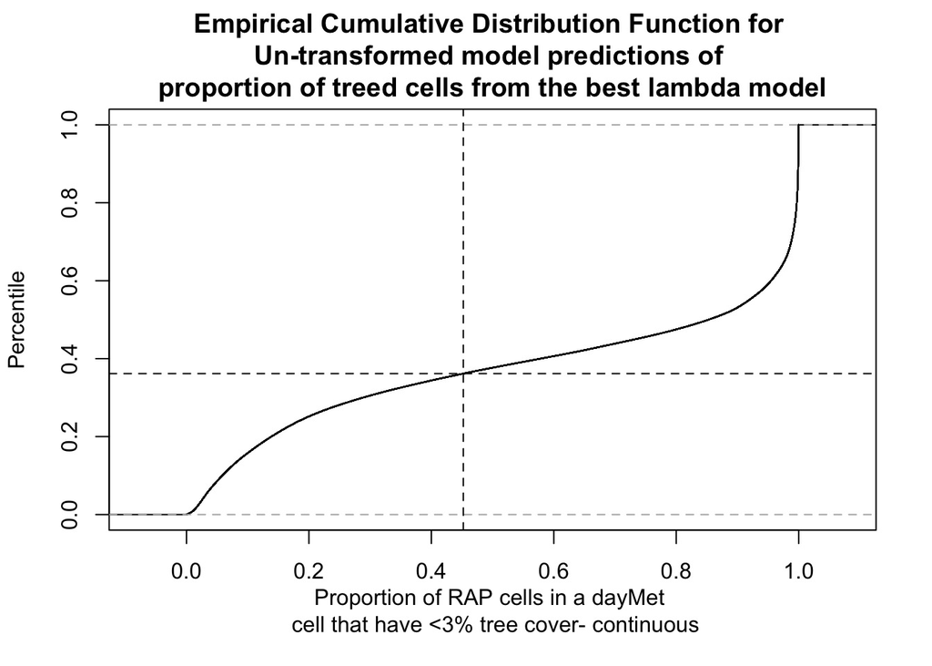

```r
## make an empirical cumulative probability function plot of the model predictions on wall-to-wall data
pred_glm1_w2w_cdf <- stats::ecdf(pred_glm1_w2w[,"fracNotForest_pred"])
# ## find the quantile of observations that corresponds to the desired proportion of unforested locations
thresholdPercentile_bestLambda <- pred_glm1_w2w_cdf(best_threshold_bestLambda)
  #quantile(pred_glm1_w2w$TotalTreeCover_binom_pred %>% na.omit(), probs = best_threshold_bestLambda)
# get P(forest) for percentiles +/- 0.05 from the percentile of the optimal threshold

# plot the ecdf
plot(pred_glm1_w2w_cdf, xlab = c("Proportion of RAP cells in a dayMet \n cell that have <3% tree cover- continuous"), ylab = "Percentile",
     main = "Empirical Cumulative Distribution Function for \nUn-transformed model predictions of \nproportion of treed cells from the best lambda model")

# lines for optimal threshold
abline(v = best_threshold_bestLambda, lty = 2)
abline(h = thresholdPercentile_bestLambda, lty = 2)
```

For second-best lambda model

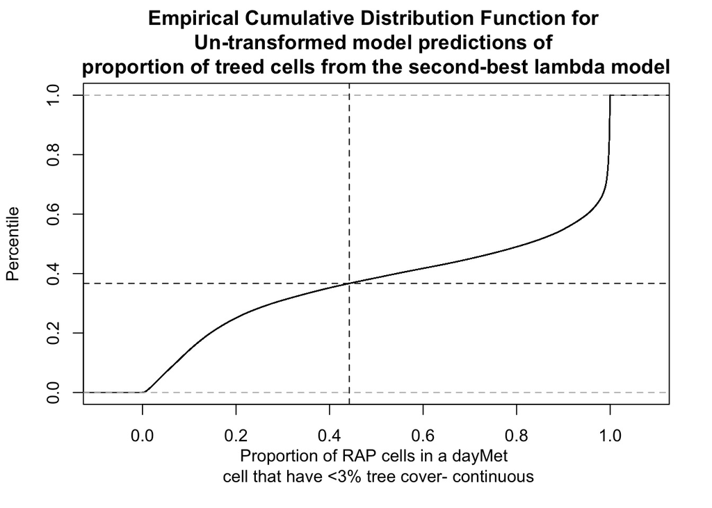

```r
## make an empirical cumulative probability function plot of the model predictions on wall-to-wall data
pred_glm1_1se_w2w_cdf <- stats::ecdf(pred_glm1_1se_w2w[,"fracNotForest_pred"])
# ## find the quantile of observations that corresponds to the desired proportion of unforested locations
thresholdPercentile_secondBestLambda <- pred_glm1_1se_w2w_cdf(best_threshold_secondBest)
  #quantile(pred_glm1_w2w$TotalTreeCover_binom_pred %>% na.omit(), probs = best_threshold_bestLambda)
# get P(forest) for percentiles +/- 0.05 from the percentile of the optimal threshold

# plot the ecdf
plot(pred_glm1_1se_w2w_cdf, xlab = c("Proportion of RAP cells in a dayMet \n cell that have <3% tree cover- continuous"), ylab = "Percentile",
     main = "Empirical Cumulative Distribution Function for \nUn-transformed model predictions of \nproportion of treed cells from the second-best lambda model")

# lines for optimal threshold
abline(v = best_threshold_secondBest, lty = 2)
abline(h = thresholdPercentile_secondBestLambda, lty = 2)
```

We use the thresholds identified above to make continuous predictions of proportion of trees binary

```r
## for full dataset
# best lambda model
# "binomialize" the continuous predictions
pred_glm1_full <- pred_glm1_full %>%
  mutate(fracNotForest_pred_binary = fracNotForest_pred,
    fracNotForest_pred_binary = replace(fracNotForest_pred_binary, fracNotForest_pred_binary > best_threshold_bestLambda, 1),
         fracNotForest_pred_binary = replace(fracNotForest_pred_binary, fracNotForest_pred_binary <= best_threshold_bestLambda, 0))

# second-best lambda model
# "binomialize" the continuouse predictions
pred_glm1_1se_full <- pred_glm1_1se_full %>%
  mutate(fracNotForest_pred_binary = fracNotForest_pred,
    fracNotForest_pred_binary = replace(fracNotForest_pred_binary, fracNotForest_pred_binary > best_threshold_bestLambda, 1),
         fracNotForest_pred_binary = replace(fracNotForest_pred_binary, fracNotForest_pred_binary <= best_threshold_bestLambda, 0))

## for wall-to-wall data
# best lambda model
# "binomialize" the continuous predictions
pred_glm1_w2w <- pred_glm1_w2w %>%
  mutate(fracNotForest_pred_binary = fracNotForest_pred,
    fracNotForest_pred_binary = replace(fracNotForest_pred_binary, fracNotForest_pred_binary > best_threshold_bestLambda, 1),
         fracNotForest_pred_binary = replace(fracNotForest_pred_binary, fracNotForest_pred_binary <= best_threshold_bestLambda, 0))

# second-best lambda model
# "binomialize" the continuouse predictions
pred_glm1_1se_w2w <- pred_glm1_1se_w2w %>%
 mutate(fracNotForest_pred_binary = fracNotForest_pred,
    fracNotForest_pred_binary = replace(fracNotForest_pred_binary, fracNotForest_pred_binary > best_threshold_bestLambda, 1),
         fracNotForest_pred_binary = replace(fracNotForest_pred_binary, fracNotForest_pred_binary <= best_threshold_bestLambda, 0))
```

### Identify Misclassifications

```r
## first, need to bin prediction data
# best lambda model
pred_glm1_full$fracNotForest_binary <- pred_glm1_full$fracNotForest
pred_glm1_full[pred_glm1_full$fracNotForest_binary <= .5, "fracNotForest_binary"] <- 0
pred_glm1_full[pred_glm1_full$fracNotForest_binary > .5, "fracNotForest_binary"] <- 1
# second-best lambda model
pred_glm1_1se_full$fracNotForest_binary <- pred_glm1_1se_full$fracNotForest
pred_glm1_1se_full[pred_glm1_1se_full$fracNotForest_binary <= .5, "fracNotForest_binary"] <- 0
pred_glm1_1se_full[pred_glm1_1se_full$fracNotForest_binary > .5, "fracNotForest_binary"] <- 1

# true positive = tree (1)
# false positive = model says tree, data says no-tree (2)
# true negative = no tree (3)
# false negative = model says no tree, data says tree (4)

# best-lambda model -- full dataset
pred_glm1_full$missClass <- NA
pred_glm1_full[pred_glm1_full$fracNotForest_binary == 1 &
                 pred_glm1_full$fracNotForest_pred_binary == 1, "missClass"] <- 1
pred_glm1_full[pred_glm1_full$fracNotForest_binary == 0 &
                 pred_glm1_full$fracNotForest_pred_binary == 0, "missClass"] <- 3
pred_glm1_full[pred_glm1_full$fracNotForest_binary == 0 &
                 pred_glm1_full$fracNotForest_pred_binary == 1, "missClass"] <- 2
pred_glm1_full[pred_glm1_full$fracNotForest_binary == 1 &
                 pred_glm1_full$fracNotForest_pred_binary == 0, "missClass"] <- 4

# second-best lambda model - full dataset
pred_glm1_1se_full$missClass <- NA
pred_glm1_1se_full[pred_glm1_1se_full$fracNotForest_binary == 1 &
                 pred_glm1_1se_full$fracNotForest_pred_binary == 1, "missClass"] <- 1
pred_glm1_1se_full[pred_glm1_1se_full$fracNotForest_binary == 0 &
                 pred_glm1_1se_full$fracNotForest_pred_binary == 0, "missClass"] <- 3
pred_glm1_1se_full[pred_glm1_1se_full$fracNotForest_binary == 0 &
                 pred_glm1_1se_full$fracNotForest_pred_binary == 1, "missClass"] <- 2
pred_glm1_1se_full[pred_glm1_1se_full$fracNotForest_binary == 1 &
                 pred_glm1_1se_full$fracNotForest_pred_binary == 0, "missClass"] <- 4
```

```r
# read in .tif w/ predictions of forest classification from the forest model, which we'll use later oneon dayMet grid
forestPreds_dmGrid <- terra::rast(x= "../../../Data_processed/CoverData/finalCoverData/predictionsOfForestProbOnDaymetScale.tif")
```

## Maps of Observations, Predictions, and Residuals

```r
## clean up the environment
rm(modDat_1_s, modDat_1, nonForest_rast, notForest, notForest2, test_rast_dayMet_TEMP, X_i, X_sub, climDat, climDat_noSF, climDat_scaled, climDat_Temp, climDatPred, climDatPred_extract, climDatPred_new)
gc()
```

```
##             used (Mb) gc trigger    (Mb) limit (Mb)   max used    (Mb)
## Ncells  27954070 1493  109640905  5855.5         NA  137051131  7319.4
## Vcells 979487979 7473 3111679537 23740.3      65536 3111679537 23740.3
```

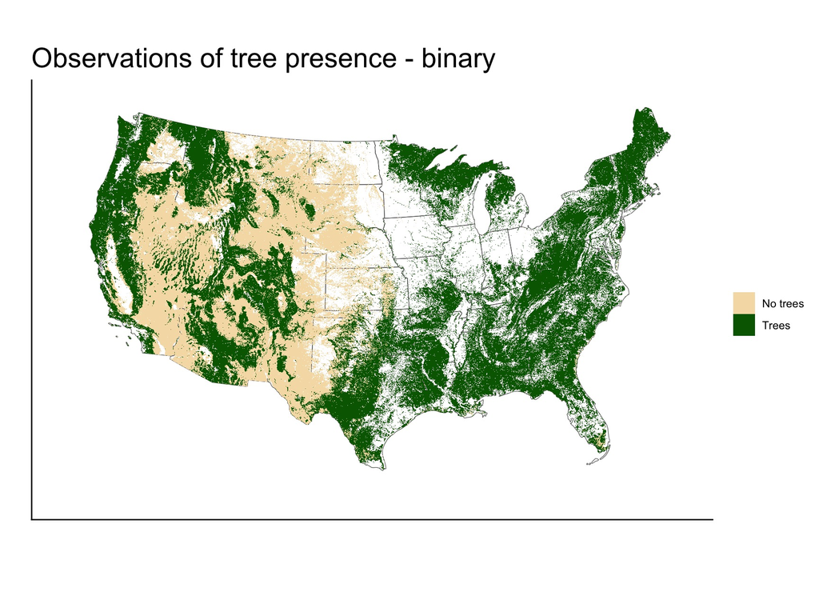

```r
## get information for plotting
# aggregate to a grid of 8km x 8km cells
test_rast <- test_rastTemp #%>%
 #terra::aggregate(fact = 8, fun = "mean")#%>%

# function for getting the statistical mode
Mode <- function(x, ...) {
  ux <- unique(x)
  ux[which.max(tabulate(match(x, ux)))]
}

# string w/ crs of veg data
crs_veg <- "PROJCRS[\"unnamed\",\n    BASEGEOGCRS[\"unknown\",\n        DATUM[\"unknown\",\n            ELLIPSOID[\"Spheroid\",6378137,298.257223563,\n                LENGTHUNIT[\"metre\",1,\n                    ID[\"EPSG\",9001]]]],\n        PRIMEM[\"Greenwich\",0,\n            ANGLEUNIT[\"degree\",0.0174532925199433,\n                ID[\"EPSG\",9122]]]],\n    CONVERSION[\"Lambert Conic Conformal (2SP)\",\n        METHOD[\"Lambert Conic Conformal (2SP)\",\n            ID[\"EPSG\",9802]],\n        PARAMETER[\"Latitude of false origin\",42.5,\n            ANGLEUNIT[\"degree\",0.0174532925199433],\n            ID[\"EPSG\",8821]],\n        PARAMETER[\"Longitude of false origin\",-100,\n            ANGLEUNIT[\"degree\",0.0174532925199433],\n            ID[\"EPSG\",8822]],\n        PARAMETER[\"Latitude of 1st standard parallel\",25,\n            ANGLEUNIT[\"degree\",0.0174532925199433],\n            ID[\"EPSG\",8823]],\n        PARAMETER[\"Latitude of 2nd standard parallel\",60,\n            ANGLEUNIT[\"degree\",0.0174532925199433],\n            ID[\"EPSG\",8824]],\n        PARAMETER[\"Easting at false origin\",0,\n            LENGTHUNIT[\"metre\",1],\n            ID[\"EPSG\",8826]],\n        PARAMETER[\"Northing at false origin\",0,\n            LENGTHUNIT[\"metre\",1],\n            ID[\"EPSG\",8827]]],\n    CS[Cartesian,2],\n        AXIS[\"easting\",east,\n            ORDER[1],\n            LENGTHUNIT[\"metre\",1,\n                ID[\"EPSG\",9001]]],\n        AXIS[\"northing\",north,\n            ORDER[2],\n            LENGTHUNIT[\"metre\",1,\n                ID[\"EPSG\",9001]]]]"
# make a multi-layer raster w/ layers for each variable of interest
pred_glm1_full_sf <- pred_glm1_full %>%
  st_as_sf(coords = c("x", "y"), crs = crs(crs_veg)) %>%
  st_transform(crs(test_rast)) %>%
  terra::vect()
testRast2 <- lapply(c("fracNotForest_binary", "fracNotForest_pred", "fracNotForest_pred_binary", "resid", "missClass"), FUN = function(x) {
  # S4 method for class 'data.frame'
  if (x %in% c("fracNotForest_binary", "fracNotForest_pred", "fracNotForest_pred_binary", "resid")) {
    temp <- terra::rasterize(x = pred_glm1_full_sf, y = test_rast,
                         field = x, fun = mean, na.rm = TRUE)
    names(temp) <- x
  } else {
    temp <- terra::rasterize(x = pred_glm1_full_sf, y = test_rast,
                         field = x, fun = Mode, na.rm = TRUE)
    # get the % aggreement between values in the dayMetx8 cell
    temp2 <- terra::rasterize(x = pred_glm1_full_sf, y = test_rast$daymet_v4_prcp_monttl_na_1980_1,
                         field = x, fun = function(y) {
                           yTemp <- y[!is.na(y)]
                           yMode <- Mode(yTemp)
                           (sum(yTemp == yMode)/length(yTemp))*100
                         })
    temp <- c(as.factor(temp$missClass), temp2)
    names(temp) <- c("missClass", "PercAgreement")
  }

 return(temp)
  }
)

pred_glm1_full_RAST <- c(testRast2[[1]], testRast2[[2]], testRast2[[3]], testRast2[[4]], testRast2[[5]])

# reproject state boundaries
cropped_states_2 <- cropped_states  %>%
  sf::st_transform(sf::st_crs(test_rast))

# make figure of treed/un-treed - binary
map_obs_bin <- ggplot() +
#geom_spatraster(data = pred_glm1_full_RAST, aes(fill = fracNotForest), maxcell = 50000000) +
  geom_sf(data=cropped_states_2 ,fill=NA ) +
  geom_raster(data = pred_glm1_full_RAST, aes(x = x,
                   y = y,
                   fill = as.character(fracNotForest_binary)), maxcell = 5e+10) +
 xlim(-2150000, 2510000) +
 ylim(-2005000, 1000000) +
  coord_sf(datum = st_crs(test_rastTemp)) +
             scale_fill_viridis_c(na.value = "white", "magma", direction = -1, limits = c(0,212)) +
 #geom_sf(data = pred_glm1_full_RAST, aes(col = TotalTreeCover)) +
  # stat_summary_2d(data = plotObs, aes(x = x, y = y, z = TotalTreeCover), fun = mean, binwidth = .05) +
labs(title = paste0("Observations of tree presence - binary"), x = "", y = ""
     ) +
   scale_fill_manual(name = "",
                     values = c("wheat", "darkgreen"),
                     labels = c("No trees", "Trees"),
                    na.translate = FALSE) +
  # scale_fill_gradient2(low = "brown",
  #                      mid = "wheat" ,
  #                      high = "forestgreen" ,
  #                      midpoint = 0,   na.value = "white") +
  theme(axis.text = element_blank(),
                   strip.text = element_text(size = 15),
                   title = element_text(size = 18),
                   axis.ticks = element_blank())
# # make figure of treed/un-treed - continuous
# map_obs_cont <- ggplot() +
# geom_spatraster(data = pred_glm1_full_RAST, aes(fill = fracNotForest), maxcell = 50000000) +
#   geom_sf(data=cropped_states_2 ,fill=NA ) +
#   #geom_raster(data = pred_glm1_full_RAST, aes(x = x,
#    #                y = y,
#     #               fill = as.character(fracNotForest)), maxcell = 5e+10) +
#  xlim(-2150000, 2510000) +
#  ylim(-2005000, 1000000) +
#   coord_sf(datum = st_crs(test_rastTemp)) +
#              scale_fill_viridis_c(na.value = "white", "magma", direction = -1, limits = c(0,212)) +
#  #geom_sf(data = pred_glm1_full_RAST, aes(col = TotalTreeCover)) +
#   # stat_summary_2d(data = plotObs, aes(x = x, y = y, z = TotalTreeCover), fun = mean, binwidth = .05) +
# labs(title = paste0("Observations of tree presence - continuous"), x = "", y = ""
#      ) +
#    # scale_fill_manual(name = "",
#    #                   values = c("wheat", "darkgreen"),
#    #                   labels = c("No trees", "Trees"),
#    #                  na.translate = FALSE) +
#   scale_fill_gradient2(low = "brown",
#                        mid = "wheat" ,
#                        high = "forestgreen" ,
#                        midpoint = 0,   na.value = "white") +
#   theme(axis.text = element_blank(),
#                    strip.text = element_text(size = 15),
#                    title = element_text(size = 18),
#                    axis.ticks = element_blank())
#
# #add inset
#  inset_plot <-  ggplot(pred_glm1_full) +
#    geom_density(aes(fracNotForest)) +
#       theme_bw(base_size=9) +  ## makes everything smaller
#       theme(panel.background = element_rect(fill="transparent"),  ## white plot background
#             panel.border = element_blank(),
# axis.title.y = element_blank(),
# axis.title.x = element_blank(),
# axis.text.x = element_text(size=rel(2)), ## tiny axis text
# axis.text.y = element_text(size=rel(2)), ## tiny axis text
# axis.line.x = element_line(size = .5),
# axis.line.y = element_line(size = .5),
# panel.grid.major = element_blank(),
# panel.grid.minor = element_blank(),
# plot.background = element_blank(),
# strip.background = element_blank(),
# strip.text = element_blank())
#
#  map_obs_cont <-    map_obs_cont +   annotation_custom(grob = ggplotGrob(inset_plot), ymin = -2028000, ymax=-1205000, xmin=-2280000, xmax=-180000 )

(map_obs_bin)
```

```r
 # (map_obs_cont)
```

### Predictions on the full dataset using the *best lambda* model

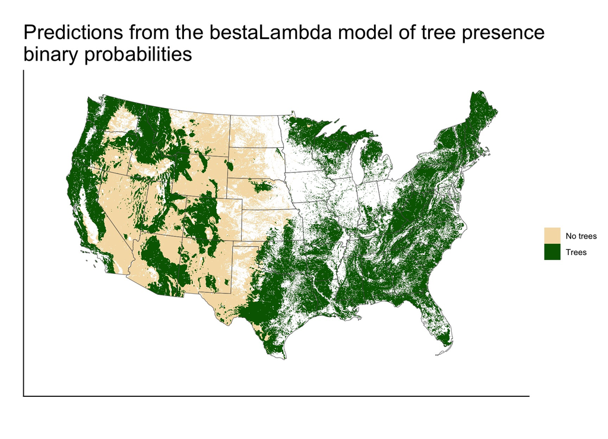

```r
# make figure of binomialized tree/no-tree
map_preds1 <- ggplot() +
   geom_raster(data = pred_glm1_full_RAST, aes(x = x,
                   y = y,
                   fill = as.character(fracNotForest_pred_binary)), maxcell = 5e+10) +
#geom_spatraster(data = pred_glm1_full_RAST, aes(fill = fracNotForest_pred_binary), maxcell = 20000000) +
    geom_sf(data=cropped_states_2 ,fill=NA ) +
labs(title = paste0("Predictions from the bestaLambda model of tree presence \nbinary probabilities"), x = "", y = "") +
   scale_fill_manual(name = "",
                     values = c("wheat", "darkgreen"),
                     labels = c("No trees", "Trees"),
                    na.translate = FALSE) +
  coord_sf(datum = st_crs(test_rastTemp)) +
    theme(axis.text = element_blank(),
                   strip.text = element_text(size = 15),
                   title = element_text(size = 18),
                   axis.ticks = element_blank()) +
 xlim(-2150000, 2510000) +
 ylim(-2005000, 1000000)

#  make figure of continuous tree/no-tree
map_preds1_cont <- ggplot() +
geom_spatraster(data = pred_glm1_full_RAST, aes(fill = fracNotForest_pred), maxcell = 50000000) +
  geom_sf(data=cropped_states_2 ,fill=NA ) +
  #geom_raster(data = pred_glm1_full_RAST, aes(x = x,
   #                y = y,
    #               fill = as.character(fracNotForest)), maxcell = 5e+10) +
 xlim(-2150000, 2510000) +
 ylim(-2005000, 1000000) +
  coord_sf(datum = st_crs(test_rastTemp)) +
             scale_fill_viridis_c(na.value = "white", "magma", direction = -1, limits = c(0,212)) +
 #geom_sf(data = pred_glm1_full_RAST, aes(col = TotalTreeCover)) +
  # stat_summary_2d(data = plotObs, aes(x = x, y = y, z = TotalTreeCover), fun = mean, binwidth = .05) +
labs(title = paste0("Predictions from the bestaLambda model of tree presence \ncontinous predictions"), x = "", y = ""
     ) +
   # scale_fill_manual(name = "",
   #                   values = c("wheat", "darkgreen"),
   #                   labels = c("No trees", "Trees"),
   #                  na.translate = FALSE) +
  scale_fill_gradient2(low = "brown",
                       mid = "wheat" ,
                       high = "forestgreen" ,
                       midpoint = 0,   na.value = "white") +
  theme(axis.text = element_blank(),
                   strip.text = element_text(size = 15),
                   title = element_text(size = 18),
                   axis.ticks = element_blank())

#add inset
 inset_plot <-  ggplot(pred_glm1_full) +
   geom_density(aes(fracNotForest_pred)) +
      theme_bw(base_size=9) +  ## makes everything smaller
      theme(panel.background = element_rect(fill="transparent"),  ## white plot background
            panel.border = element_blank(),
axis.title.y = element_blank(),
axis.title.x = element_blank(),
axis.text.x = element_text(size=rel(2)), ## tiny axis text
axis.text.y = element_text(size=rel(2)), ## tiny axis text
axis.line.x = element_line(size = .5),
axis.line.y = element_line(size = .5),
panel.grid.major = element_blank(),
panel.grid.minor = element_blank(),
plot.background = element_blank(),
strip.background = element_blank(),
strip.text = element_blank())

 map_preds1_cont <-    map_preds1_cont +   annotation_custom(grob = ggplotGrob(inset_plot), ymin = -2028000, ymax=-1205000, xmin=-2280000, xmax=-180000 )


(map_preds1)
```

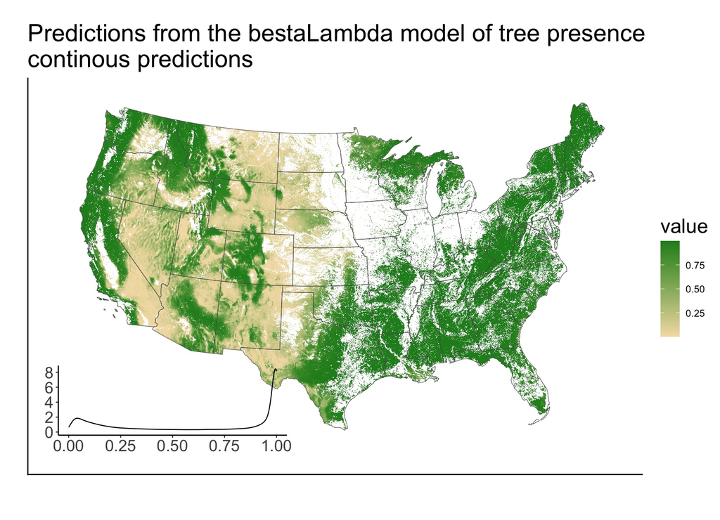

```r
(map_preds1_cont)
```

### Predictions on the full dataset using the *second best lambda* model

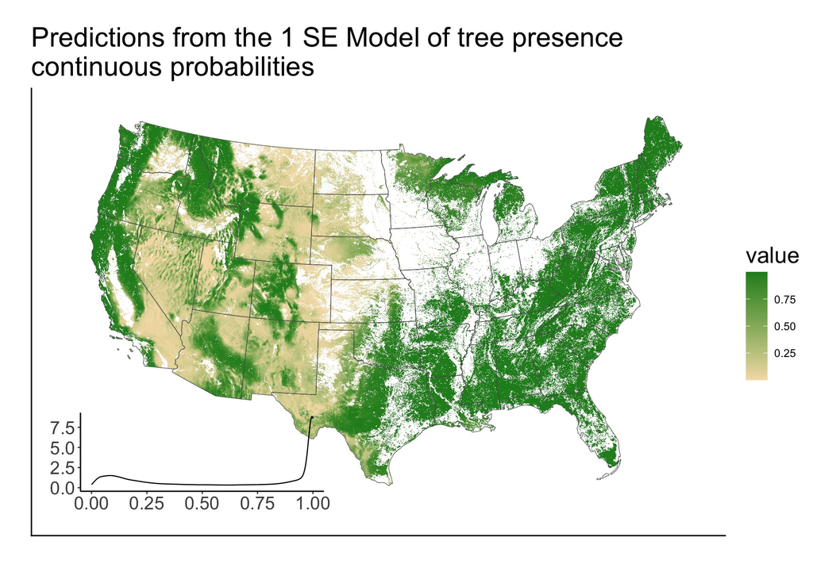

```r
if ( name_secondBestMod == "Intercept_Only") {
  print("The next best lambda model only contains one predictor (an intercept)")
} else {
  pred_glm1_1se_full_sf <- pred_glm1_1se_full %>%
  st_as_sf(coords = c("x", "y"), crs = crs(crs_veg)) %>%
  st_transform(crs(test_rast)) %>%
  terra::vect()
  # make a raster of the full dataset
# make a multi-layer raster w/ layers for each variable of interest
testRast3 <- lapply(c( "fracNotForest_binary", "fracNotForest_pred", "fracNotForest_pred_binary", "resid", "missClass"), FUN = function(x) {
  # S4 method for class 'data.frame'
 if (x %in% c("fracNotForest_binary", "fracNotForest_pred", "fracNotForest_pred_binary", "resid")) {
    temp <- terra::rasterize(x = pred_glm1_1se_full_sf, y = test_rast,
                         field = x, fun = mean, na.rm = TRUE)
    names(temp) <- x
  } else {
    temp <- terra::rasterize(x = pred_glm1_1se_full_sf, y = test_rast,
                         field = x, fun = Mode, na.rm = TRUE)
    # get the % aggreement between values in the dayMetx8 cell
    temp2 <- terra::rasterize(x = pred_glm1_1se_full_sf, y = test_rast$daymet_v4_prcp_monttl_na_1980_1,
                         field = x, fun = function(y) {
                           yTemp <- y[!is.na(y)]
                           yMode <- Mode(yTemp)
                           (sum(yTemp == yMode)/length(yTemp))*100
                         })
    temp <- c(as.factor(temp$missClass), temp2)
    names(temp) <- c("missClass", "PercAgreement")
  }

 return(temp)
  }
)
pred_glm1_1se_full_RAST <- c(testRast3[[1]], testRast3[[2]], testRast3[[3]], testRast3[[4]], testRast3[[5]])

# make figures of predictions w/ the full dataset
map_preds2_binary <- ggplot() +
   geom_raster(data = pred_glm1_1se_full_RAST, aes(x = x,
                   y = y,
                   fill = as.character(fracNotForest_pred_binary)), maxcell = 5e+10) +
#geom_spatraster(data = pred_glm1_full_RAST, aes(fill = fracNotForest_pred_binary), maxcell = 20000000) +
    geom_sf(data=cropped_states_2 ,fill=NA ) +
labs(title = paste0("Predictions from the ", name_secondBestMod, " of tree presence \nbinary probabilities"), x = "", y = "") +
  scale_fill_manual(name = "",
                     values = c("wheat", "darkgreen"),
                     labels = c("No trees", "Trees"),
                    na.translate = FALSE) +
  coord_sf(datum = st_crs(test_rastTemp)) +
    theme(axis.text = element_blank(),
                   strip.text = element_text(size = 15),
                   title = element_text(size = 18),
                   axis.ticks = element_blank()) +
 xlim(-2150000, 2510000) +
 ylim(-2005000, 1000000)


#  make figure of continuous tree/no-tree
map_preds2_cont <- ggplot() +
geom_spatraster(data = pred_glm1_1se_full_RAST, aes(fill = fracNotForest_pred), maxcell = 50000000) +
  geom_sf(data=cropped_states_2 ,fill=NA ) +
  #geom_raster(data = pred_glm1_full_RAST, aes(x = x,
   #                y = y,
    #               fill = as.character(fracNotForest)), maxcell = 5e+10) +
 xlim(-2150000, 2510000) +
 ylim(-2005000, 1000000) +
  coord_sf(datum = st_crs(test_rastTemp)) +
             scale_fill_viridis_c(na.value = "white", "magma", direction = -1, limits = c(0,212)) +
 #geom_sf(data = pred_glm1_full_RAST, aes(col = TotalTreeCover)) +
  # stat_summary_2d(data = plotObs, aes(x = x, y = y, z = TotalTreeCover), fun = mean, binwidth = .05) +
labs(title = paste0("Predictions from the ", name_secondBestMod, " of tree presence \ncontinuous probabilities"), x = "", y = ""
     ) +
   # scale_fill_manual(name = "",
   #                   values = c("wheat", "darkgreen"),
   #                   labels = c("No trees", "Trees"),
   #                  na.translate = FALSE) +
  scale_fill_gradient2(low = "brown",
                       mid = "wheat" ,
                       high = "forestgreen" ,
                       midpoint = 0,   na.value = "white") +
  theme(axis.text = element_blank(),
                   strip.text = element_text(size = 15),
                   title = element_text(size = 18),
                   axis.ticks = element_blank())

#add inset
 inset_plot <-  ggplot(pred_glm1_1se_full) +
   geom_density(aes(fracNotForest_pred)) +
      theme_bw(base_size=9) +  ## makes everything smaller
      theme(panel.background = element_rect(fill="transparent"),  ## white plot background
            panel.border = element_blank(),
axis.title.y = element_blank(),
axis.title.x = element_blank(),
axis.text.x = element_text(size=rel(2)), ## tiny axis text
axis.text.y = element_text(size=rel(2)), ## tiny axis text
axis.line.x = element_line(size = .5),
axis.line.y = element_line(size = .5),
panel.grid.major = element_blank(),
panel.grid.minor = element_blank(),
plot.background = element_blank(),
strip.background = element_blank(),
strip.text = element_blank())

 map_preds2_cont <-    map_preds2_cont +   annotation_custom(grob = ggplotGrob(inset_plot), ymin = -2028000, ymax=-1205000, xmin=-2280000, xmax=-180000 )


(map_preds2_binary)
(map_preds2_cont)

}
```

[output not shown]

### A map of classification error of predictions on the full dataset made using the *best lambda model*

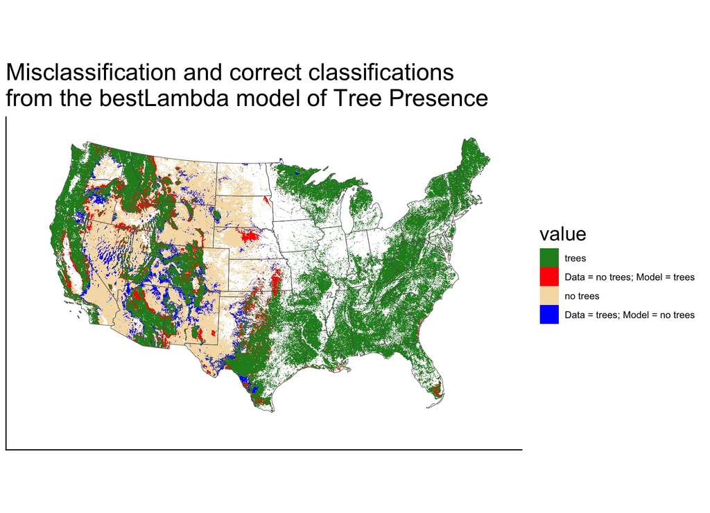

```r
# true positive = tree (1) (forest green)
# true negative = no tree (3) (wheat)
# false positive = model says tree, data says no-tree (2) (red)
# false negative = model says no tree, data says tree (4) (blue)
# make figures
map_missClass <- ggplot() +
geom_spatraster(data =pred_glm1_full_RAST
                , aes(fill= missClass), maxcell = 2000000000000) +
  geom_sf(data=cropped_states_2,fill=NA )  +
labs(title = paste0("Misclassification and correct classifications \nfrom the bestLambda model of Tree Presence")#,
     #subtitle = "bestLambda model \nvalues show are the most common classification in each 8km x 8km grid cell"
     ) +
    scale_fill_discrete(palette =
                        c("forestgreen", "red", "wheat", "blue"),
                        na.value = "white",
                        labels = c("trees", "Data = no trees; Model = trees", "no trees", "Data = trees; Model = no trees", "")) +
  coord_sf(datum = st_crs(test_rastTemp)) +
    theme(axis.text = element_blank(),
                   strip.text = element_text(size = 15),
                   title = element_text(size = 18),
                   axis.ticks = element_blank()) +
 xlim(-2150000, 2510000) +
 ylim(-2005000, 1000000)

map_missClass
```

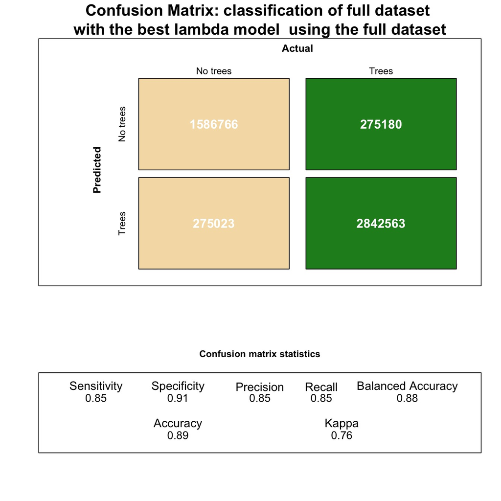

```r
# make a confusion matrix
# prepare data
matData <- pred_glm1_full %>%
  mutate(predClass = fracNotForest_pred_binary,
         obsClass = fracNotForest_binary) %>%
  mutate(predClass = replace(predClass, predClass == 0, "no trees"),
         predClass = replace(predClass, predClass == 1, "trees"),
         obsClass = replace(obsClass, obsClass == 0, "no trees"),
         obsClass = replace(obsClass, obsClass == 1, "trees")) %>%
mutate(predClass = as.factor(predClass) ,
       obsClass = as.factor(obsClass))

# make matrix as a data.frame
# confMat <-  confusionMatrix(data = matData$predClass,
#                  reference = matData$obsClass)
ConfusionTableR::binary_visualiseR(
  train_labels = as.factor(matData$predClass),
  truth_labels = as.factor(matData$obsClass),
   class_label1 = "No trees",
   class_label2 = "Trees",
   quadrant_col1 = "wheat",
   quadrant_col2 = "forestgreen",
  text_col = "white", custom_title = "Confusion Matrix: classification of full dataset \nwith the best lambda model  using the full dataset"
)
```

### A map of classification error of predictions on the full datasets made using the *second best lambda model*

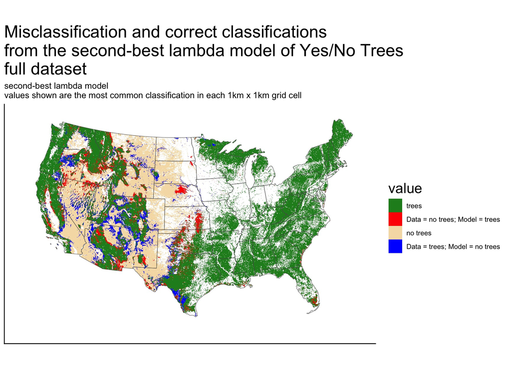

```r
### full dataset
# make figures
map_missClass <- ggplot() +
geom_spatraster(data =pred_glm1_1se_full_RAST, aes(fill= missClass), maxcell = 200000000000) +
  geom_sf(data=cropped_states_2,fill=NA )  +
labs(title = paste0("Misclassification and correct classifications \nfrom the second-best lambda model of Yes/No Trees \nfull dataset"),
     subtitle = "second-best lambda model \nvalues shown are the most common classification in each 1km x 1km grid cell") +
  scale_fill_discrete(palette =
                        c("forestgreen", "red", "wheat", "blue"),
                        na.value = "white",
                       labels = c("trees", "Data = no trees; Model = trees", "no trees", "Data = trees; Model = no trees", ""))  +
  coord_sf(datum = st_crs(test_rastTemp)) +
    theme(axis.text = element_blank(),
                   strip.text = element_text(size = 15),
                   title = element_text(size = 18),
                   axis.ticks = element_blank()) +
 xlim(-2150000, 2510000) +
 ylim(-2005000, 1000000)

map_missClass
```

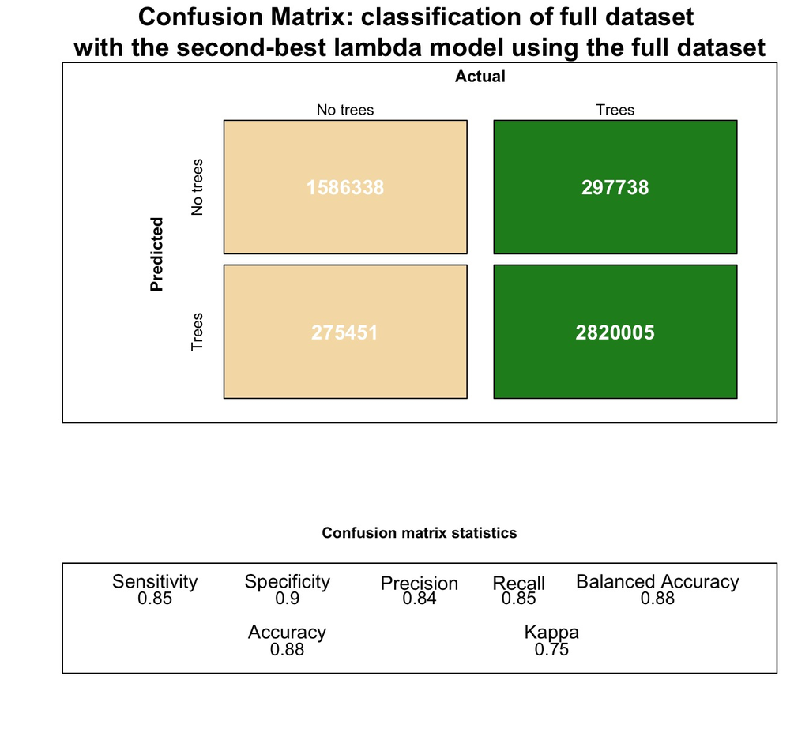

```r
# make a confusion matrix
# prepare data
matData <- pred_glm1_1se_full %>%
  mutate(predClass = fracNotForest_pred_binary,
         obsClass = fracNotForest_binary) %>%
  mutate(predClass = replace(predClass, predClass == 0, "no trees"),
         predClass = replace(predClass, predClass == 1, "trees"),
         obsClass = replace(obsClass, obsClass == 0, "no trees"),
         obsClass = replace(obsClass, obsClass == 1, "trees")) %>%
mutate(predClass = as.factor(predClass) ,
       obsClass = as.factor(obsClass))

# make matrix as a data.frame
# confMat <-  confusionMatrix(data = matData$predClass,
#                  reference = matData$obsClass)
ConfusionTableR::binary_visualiseR(
  train_labels = as.factor(matData$predClass),
  truth_labels = as.factor(matData$obsClass),
   class_label1 = "No trees",
   class_label2 = "Trees",
   quadrant_col1 = "wheat",
   quadrant_col2 = "forestgreen",
  text_col = "white", custom_title = "Confusion Matrix: classification of full dataset \nwith the second-best lambda model using the full dataset"
)
```

## Map of classification using best lambda model, *only in locations that the forest model predicts to be un-forested*

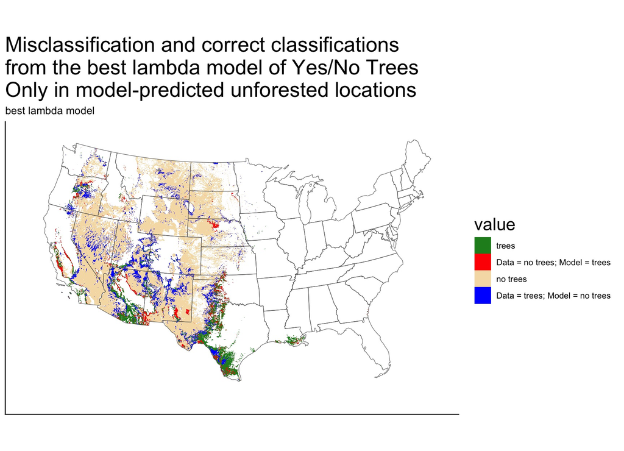

```r
## mask data based on forest classification
missClassRast_bestLambda_forestOnly <- pred_glm1_full_RAST$missClass %>%
  terra::crop(ext(forestPreds_dmGrid)) %>%
  terra::mask(mask = forestPreds_dmGrid, maskvalues = 1)
# make figures
map_missClass_nonForestOnly <- ggplot() +
geom_spatraster(data =missClassRast_bestLambda_forestOnly, aes(fill= missClass), maxcell = 2000000000) +
  geom_sf(data=cropped_states_2,fill=NA )  +
labs(title = paste0("Misclassification and correct classifications \nfrom the best lambda model of Yes/No Trees \nOnly in model-predicted unforested locations"),
     subtitle = "best lambda model") +
  scale_fill_discrete(palette =
                        c("forestgreen", "red", "wheat", "blue"),
                        na.value = "white",
                       labels = c("trees", "Data = no trees; Model = trees", "no trees", "Data = trees; Model = no trees", ""))  +
  coord_sf(datum = st_crs(test_rastTemp)) +
    theme(axis.text = element_blank(),
                   strip.text = element_text(size = 15),
                   title = element_text(size = 18),
                   axis.ticks = element_blank()) +
 xlim(-2150000, 2510000) +
 ylim(-2005000, 1000000)

map_missClass_nonForestOnly
```

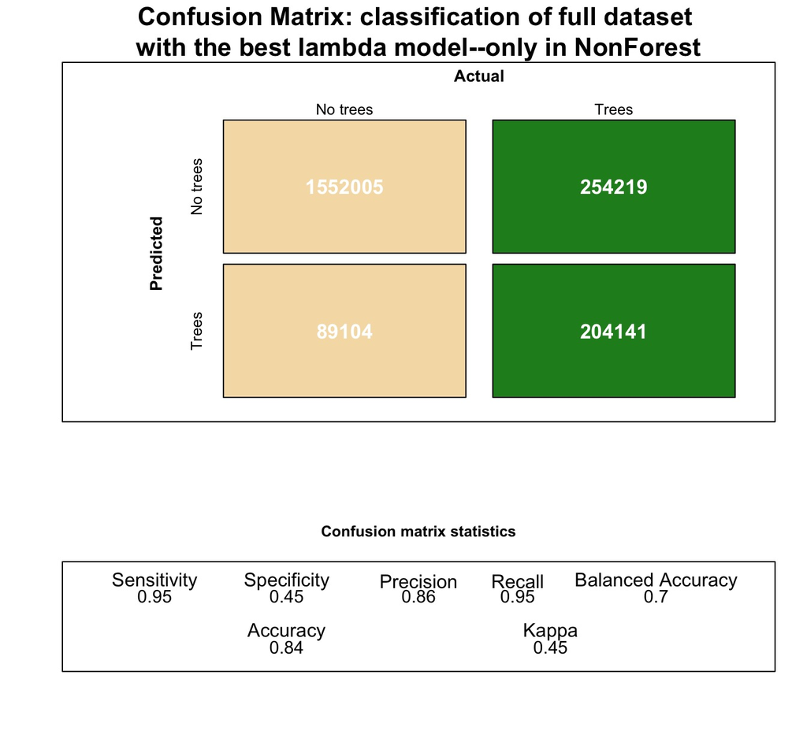

```r
# make a confusion matrix
# prepare data
matData <- terra::values(missClassRast_bestLambda_forestOnly$missClass) %>%
  as.data.frame() %>%
  drop_na()
matData$observation <- NA
matData$prediction <- NA
matData[matData$missClass == 1, c("observation", "prediction")] <- "trees"

matData[matData$missClass == 2, c("observation")] <- "no trees"
matData[matData$missClass == 2, c("prediction")] <- "trees"

matData[matData$missClass == 3, c("observation", "prediction")] <- "no trees"

matData[matData$missClass == 4, c("observation")] <- "trees"
matData[matData$missClass == 4, c("prediction")] <- "no trees"

# make matrix as a data.frame
# confMat <-  confusionMatrix(data = matData$predClass,
#                  reference = matData$obsClass)
ConfusionTableR::binary_visualiseR(
  train_labels = as.factor(matData$prediction),
  truth_labels = as.factor(matData$observation),
   class_label1 = "No trees",
   class_label2 = "Trees",
   quadrant_col1 = "wheat",
   quadrant_col2 = "forestgreen",
  text_col = "white", custom_title = "Confusion Matrix: classification of full dataset \nwith the best lambda model--only in NonForest"
)
```

## Map of classification using second-best lambda model, *only in locations that the forest model predicts to be un-forested*

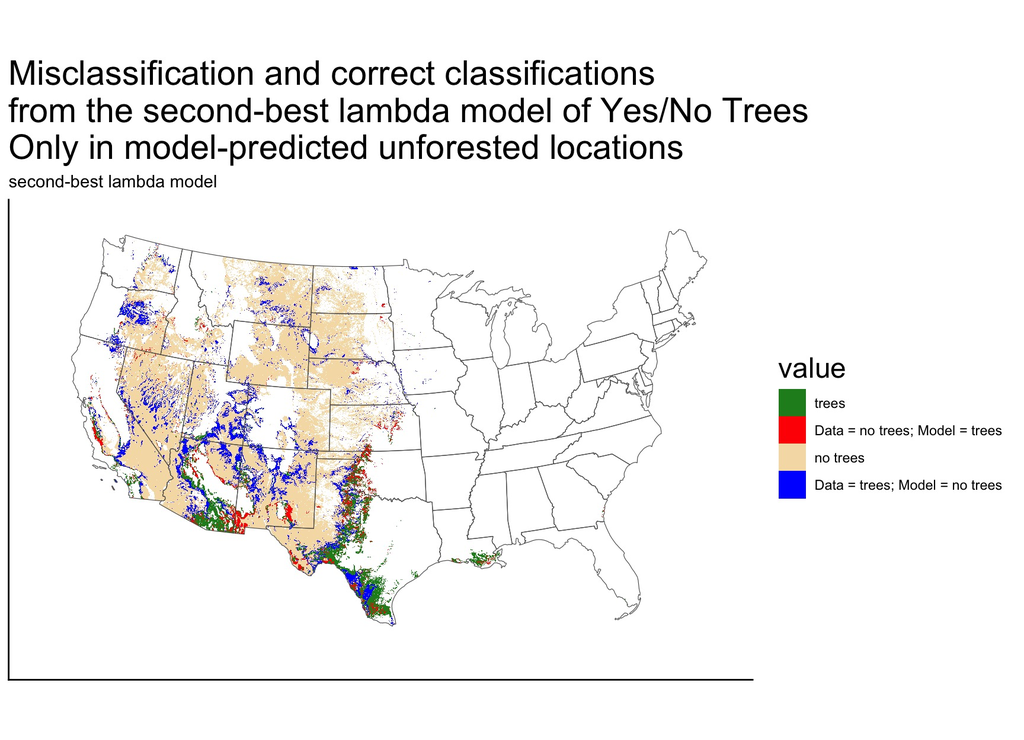

```r
## mask data based on forest classification
missClassRast_1SE_Lambda_forestOnly <- pred_glm1_1se_full_RAST$missClass %>%
  terra::crop(ext(forestPreds_dmGrid)) %>%
  terra::mask(mask = forestPreds_dmGrid, maskvalues = 1)
# make figures
map_missClass_nonForestOnly_secondBestLambda <- ggplot() +
geom_spatraster(data =missClassRast_1SE_Lambda_forestOnly, aes(fill= missClass), maxcell = 20000000) +
  geom_sf(data=cropped_states_2,fill=NA )  +
labs(title = paste0("Misclassification and correct classifications \nfrom the second-best lambda model of Yes/No Trees \nOnly in model-predicted unforested locations"),
     subtitle = "second-best lambda model") +
  scale_fill_discrete(palette =
                        c("forestgreen", "red", "wheat", "blue"),
                        na.value = "white",
                       labels = c("trees", "Data = no trees; Model = trees", "no trees", "Data = trees; Model = no trees", ""))  +
  coord_sf(datum = st_crs(test_rastTemp)) +
    theme(axis.text = element_blank(),
                   strip.text = element_text(size = 15),
                   title = element_text(size = 18),
                   axis.ticks = element_blank()) +
 xlim(-2150000, 2510000) +
 ylim(-2005000, 1000000)

map_missClass_nonForestOnly_secondBestLambda
```

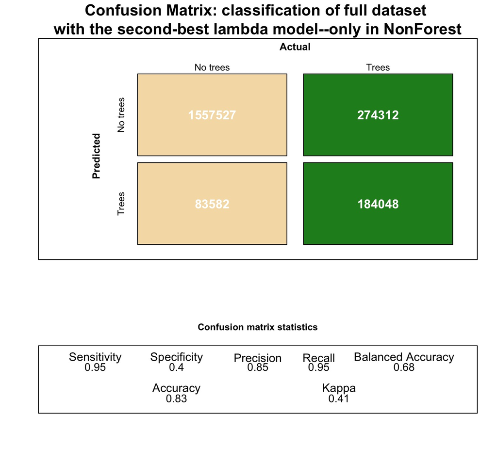

```r
# make a confusion matrix
# prepare data
matData <- terra::values(missClassRast_1SE_Lambda_forestOnly$missClass) %>%
  as.data.frame() %>%
  drop_na()
matData$observation <- NA
matData$prediction <- NA
matData[matData$missClass == 1, c("observation", "prediction")] <- "trees"

matData[matData$missClass == 2, c("observation")] <- "no trees"
matData[matData$missClass == 2, c("prediction")] <- "trees"

matData[matData$missClass == 3, c("observation", "prediction")] <- "no trees"

matData[matData$missClass == 4, c("observation")] <- "trees"
matData[matData$missClass == 4, c("prediction")] <- "no trees"

# make matrix as a data.frame
# confMat <-  confusionMatrix(data = matData$predClass,
#                  reference = matData$obsClass)
ConfusionTableR::binary_visualiseR(
  train_labels = as.factor(matData$prediction),
  truth_labels = as.factor(matData$observation),
   class_label1 = "No trees",
   class_label2 = "Trees",
   quadrant_col1 = "wheat",
   quadrant_col2 = "forestgreen",
  text_col = "white", custom_title = "Confusion Matrix: classification of full dataset \nwith the second-best lambda model--only in NonForest"
)
```

## Maps of wall-to-wall model predictions, *including* all locations that are developed, agriculture, or water, or have been burned

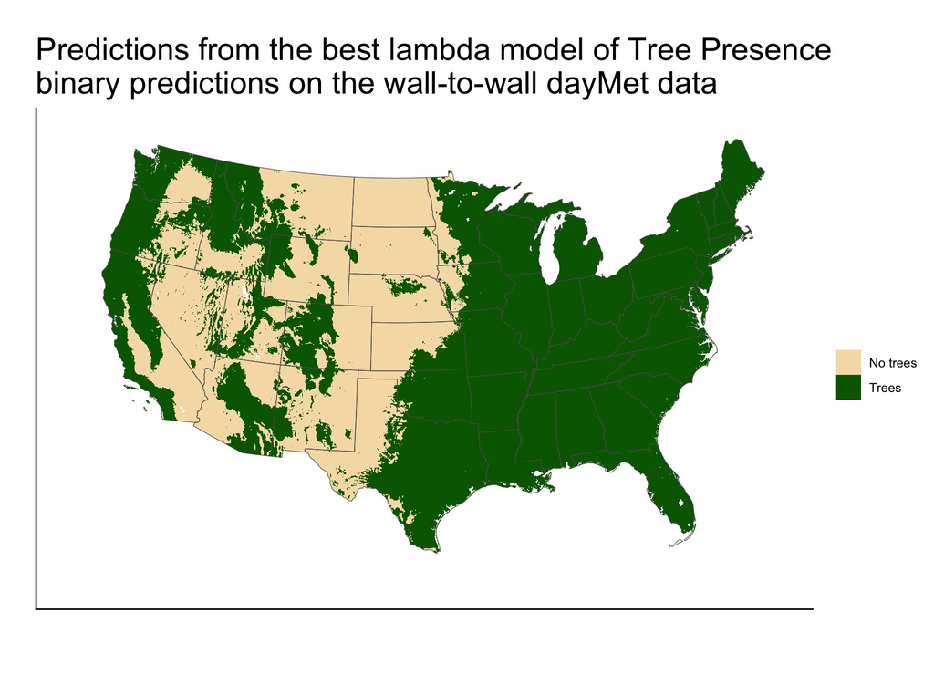

```r
### best lambda model
## rasterize
 pred_glm1_w2w_sf <- pred_glm1_w2w %>%
  st_as_sf(coords = c("Lon", "Lat"), crs = crs(crs_veg)) %>%
  st_transform(crs(test_rast)) %>%
  terra::vect()
  # make a raster of the full dataset
# make a multi-layer raster w/ layers for each variable of interest
testRast6 <- lapply(c("fracNotForest_pred_binary"), FUN = function(x) {
  # S4 method for class 'data.frame'
    temp <- terra::rasterize(x = pred_glm1_w2w_sf, y = test_rast,
                         field = x, fun = mean, na.rm = TRUE)
    names(temp) <- x
 return(temp)
  }
)
pred_glm1_w2w_RAST <- c(testRast6[[1]])

## map of binary predictions
pred_glm1_w2w_bin <- ggplot() +
geom_raster(data =  pred_glm1_w2w_RAST #%>% terra::crop(ext(-90000, 10000, -1000, 90000))#pred_glm1_w2w_RAST
                , aes(x =x, y = y,fill = as.character(fracNotForest_pred_binary)), maxcell = 20000000000) +
  geom_sf(data=cropped_states_2 ,fill=NA ) +
labs(title = paste0("Predictions from the best lambda model of Tree Presence \nbinary predictions on the wall-to-wall dayMet data"), x = "", y = "") +
  scale_fill_manual(name = "",
                     values = c("wheat", "darkgreen"),
                     labels = c("No trees", "Trees"),
                    na.translate = FALSE) +
  coord_sf(datum = st_crs(test_rastTemp)) +
    theme(axis.text = element_blank(),
                   strip.text = element_text(size = 15),
                   title = element_text(size = 18),
                   axis.ticks = element_blank()) +
 xlim(-2150000, 2510000) +
 ylim(-2005000, 1000000)


### second best lambda model
## rasterize
 pred_glm1_1se_w2w_sf <- pred_glm1_1se_w2w %>%
  st_as_sf(coords = c("Lon", "Lat"), crs = crs(crs_veg)) %>%
  st_transform(crs(test_rast)) %>%
  terra::vect()
  # make a raster of the full dataset
# make a multi-layer raster w/ layers for each variable of interest
testRast7 <- lapply(c( "fracNotForest_pred_binary"), FUN = function(x) {
  # S4 method for class 'data.frame'
    temp <- terra::rasterize(x = pred_glm1_1se_w2w_sf, y = test_rast,
                         field = x, fun = mean, na.rm = TRUE)
    names(temp) <- x
 return(temp)
  }
)
pred_glm1_1se_w2w_RAST <- c(testRast7[[1]])

## map of binary predictions
pred_glm1_1se_w2w_bin <- ggplot() +
geom_raster(data = pred_glm1_1se_w2w_RAST, aes(x = x, y = y, fill = as.character(fracNotForest_pred_binary)), maxcell = 20000000) +
  geom_sf(data=cropped_states_2 ,fill=NA ) +
labs(title = paste0("Predictions from the second-best lambda model of Tree Presence \nbinary probabilities on the wall-to-wall dayMet data"), x = "", y = "") +
  scale_fill_manual(name = "",
                     values = c("wheat", "darkgreen"),
                     labels = c("No trees", "Trees"),
                    na.translate = FALSE) +
  coord_sf(datum = st_crs(test_rastTemp)) +
    theme(axis.text = element_blank(),
                   strip.text = element_text(size = 15),
                   title = element_text(size = 18),
                   axis.ticks = element_blank()) +
 xlim(-2150000, 2510000) +
 ylim(-2005000, 1000000)

pred_glm1_w2w_bin
```

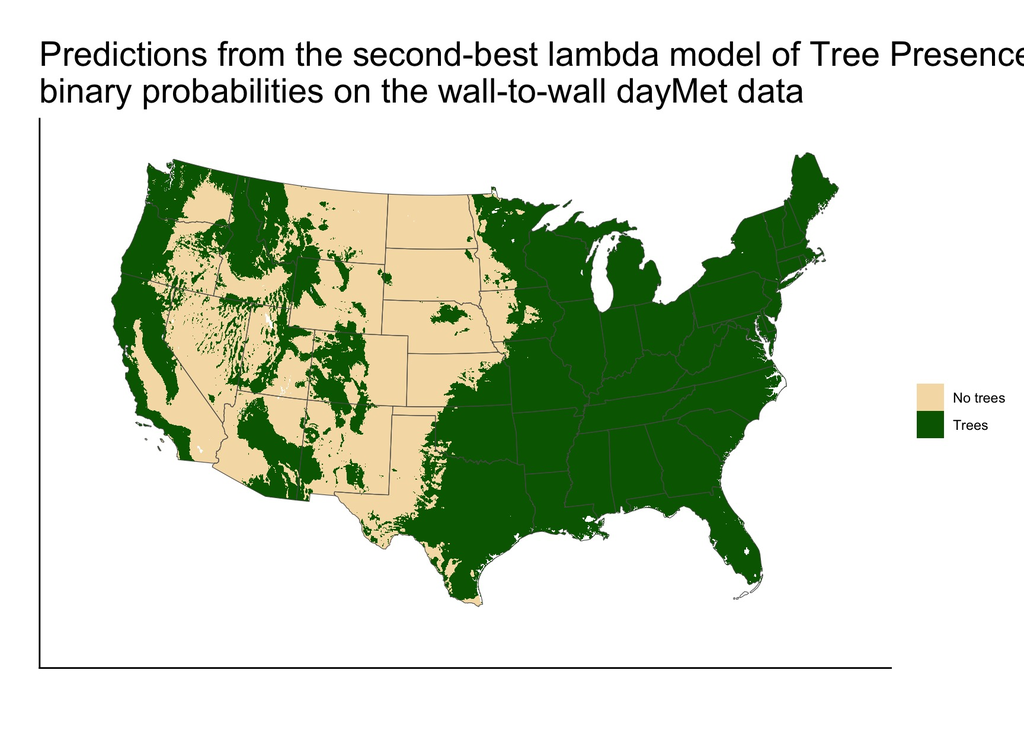

```r
pred_glm1_1se_w2w_bin
```

```r
if ( name_secondBestMod == "Intercept_Only") {
  print("The next best lambda model only contains one predictor (an intercept)")

  ## calculate Misclassification in the input pred_glm1 or pred_glm1se datasets
  pred_glm1_full$missClass2 <- pred_glm1_full$fracNotForest - pred_glm1_full$fracNotForest_pred_binary

  # plot misclassifications against Year
# yearResidMod_bestLambda <- ggplot(pred_glm1_full) +
#   geom_point(aes(x = jitter(Year), y = jitter(missClass2)), alpha = .1) +
#   geom_hline(aes(yintercept = 0), lty = 2, col = "red") +
#   geom_smooth(aes(x = Year, y = missClass2), method = "lm") +
#   xlab("Year") +
#   ylab("misclassifications") +
#   ggtitle("from best lamba model")

# plot misclassifications against Lat
latResidMod_bestLambda <- ggplot(pred_glm1_full) +
  geom_point(aes(x = y, y = jitter(missClass2)), alpha = .1) +
  geom_hline(aes(yintercept = 0), lty = 2, col = "red") +
  geom_smooth(aes(x = y, y = missClass2)) +
  xlab("Latitude") +
  ylab("misclassifications") +
  ggtitle("from best lamba model")

# plot misclassifications against Long
longResidMod_bestLambda <- ggplot(pred_glm1_full) +
  geom_point(aes(x = x, y = jitter(missClass2)), alpha = .1) +
  geom_hline(aes(yintercept = 0), lty = 2, col = "red") +
  geom_smooth(aes(x = x, y = missClass2)) +
  xlab("Longitude") +
  ylab("misclassifications") +
  ggtitle("from best lamba model")
library(patchwork)
#(yearResidMod_bestLambda ) /
(  latResidMod_bestLambda ) /
(  longResidMod_bestLambda )
} else {

  ## calculate missClassification in the input pred_glm1 or pred_glm1se datasets
  pred_glm1_full$missClass2 <- pred_glm1_full$fracNotForest - pred_glm1_full$fracNotForest_pred_binary
  pred_glm1_1se_full$missClass2 <- pred_glm1_1se_full$fracNotForest - pred_glm1_1se_full$fracNotForest_pred_binary

# plot misclassifications against Year
# yearResidMod_bestLambda <- ggplot(pred_glm1_full) +
#   geom_point(aes(x = jitter(Year), y = jitter(missClass2)), alpha = .1) +
#   geom_hline(aes(yintercept = 0), lty = 2, col = "red") +
#   geom_smooth(aes(x = Year, y = missClass2), method = "lm") +
#   xlab("Year") +
#   ylab("misclassifications") +
#   ggtitle("from best lamba model")
# yearResidMod_1seLambda <- ggplot(pred_glm1_1se_full) +
#   geom_point(aes(x = jitter(Year), y = jitter(missClass2)), alpha = .1) +
#   geom_hline(aes(yintercept = 0), lty = 2, col = "red") +
#   geom_smooth(aes(x = Year, y = missClass2), method = "lm") +
#   xlab("Year") +
#   ylab("misclassifications") +
#   ggtitle(paste0("from ", name_secondBestMod))

# plot misclassifications against Lat
latResidMod_bestLambda <- ggplot(pred_glm1_full) +
  geom_point(aes(x = y, y = jitter(missClass2)), alpha = .1) +
  geom_hline(aes(yintercept = 0), lty = 2, col = "red") +
  geom_smooth(aes(x = y, y = missClass2)) +
  xlab("Latitude") +
  ylab("misclassifications") +
  ggtitle("from best lamba model")
latResidMod_1seLambda <- ggplot(pred_glm1_1se_full) +
  geom_point(aes(x = y, y = jitter(missClass2)), alpha = .1) +
  geom_hline(aes(yintercept = 0), lty = 2, col = "red") +
  geom_smooth(aes(x = y, y = missClass2)) +
  xlab("Latitude") +
  ylab("misclassifications") +
  ggtitle(paste0("from ", name_secondBestMod))

# plot misclassifications against Long
longResidMod_bestLambda <- ggplot(pred_glm1_full) +
  geom_point(aes(x = x, y = jitter(missClass2)), alpha = .1) +
  geom_hline(aes(yintercept = 0), lty = 2, col = "red") +
  geom_smooth(aes(x = x, y = missClass2)) +
  xlab("Longitude") +
  ylab("misclassifications") +
  ggtitle("from best lamba model")
longResidMod_1seLambda <- ggplot(pred_glm1_1se_full %>% sample) +
  geom_point(aes(x = x, y = jitter(missClass2)), alpha = .1) +
  geom_hline(aes(yintercept = 0), lty = 2, col = "red") +
  geom_smooth(aes(x = x, y = missClass2)) +
  xlab("Longitude") +
  ylab("misclassifications") +
  ggtitle(paste0("from ", name_secondBestMod))

library(patchwork)
#(yearResidMod_bestLambda + yearResidMod_1seLambda) /
(  latResidMod_bestLambda + latResidMod_1seLambda) /
(  longResidMod_bestLambda + longResidMod_1seLambda)
}
```

[output not shown]

### Quantile plots - comparing “binary” training data to “binary” model-predictions (i.e. converting the continuous model predictions to discrete values (1 or 0) based on the previously-identified optimal threshold)

```r
response_vars <- c("fracNotForest_binary", "fracNotForest_pred_binary")
# get deciles for best lambda model
if (length(prednames_fig) == 0) {
  print("The best lambda model only contains one predictor (an intercept), so decile plots aren't possible to generate")
} else {
  pred_glm1_deciles <- predvars2deciles(pred_glm1_full,
                                      response_vars = response_vars,
                                        pred_vars = prednames_fig,
                                       cut_points = seq(0, 1, 0.01))
}
# get deciles for 1 SE lambda model
if ( name_secondBestMod == "Intercept_Only") {
  print("The next best lambda model only contains one predictor (an intercept)")} else {
  pred_glm1_deciles_1se <- predvars2deciles(pred_glm1_1se_full,
                                      response_vars = response_vars,
                                        pred_vars = prednames_secondBestMod,
                                       cut_points = seq(0, 1, 0.01))
  }
```

Below are quantile plots for the *best lambda model* (note that the predictor variables are scaled)

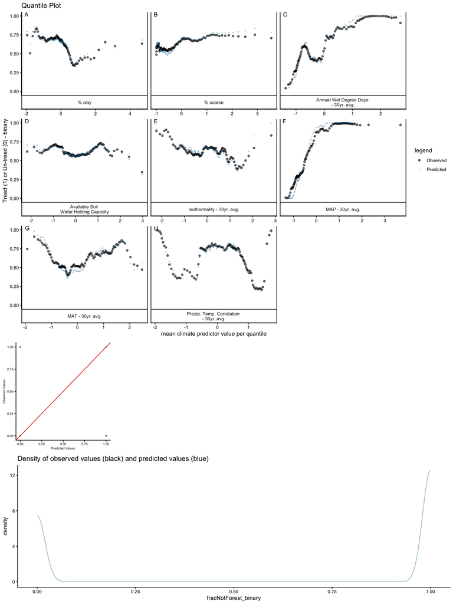

```r
if (length(prednames_fig) == 0) {
  print("The model only contains one predictor (an intercept), so decile plots aren't possible to generate")
} else {

  #####
# publication quality version
g3 <- decile_dotplot_pq(df = pred_glm1_deciles, response = c("fracNotForest_binary", paste0("fracNotForest", "_pred_binary")), IQR = FALSE,
                        CI = FALSE
                        ) + ggtitle("Quantile Plot") +
  ggplot2::labs(y = "Treed (1) or Un-treed (0) - binary")

g4 <- add_dotplot_inset(g3, df = pred_glm1_deciles, response = c("fracNotForest_binary", paste0("fracNotForest", "_pred_binary")), dfRaw = pred_glm1_full, add_smooth = TRUE, deciles = FALSE)


if(save_figs) {
  # png(paste0("../../../Figures/CoverDatFigures/ figures/quantile_plots/quantile_plot_", response,  "_",ecoregion,".png"),
  #    units = "in", res = 600, width = 5.5, height = 3.5 )
  #   print(g4)
  # dev.off()
}

# make a density plot
 g4 <- ggarrange(g4, ggplot(pred_glm1_full) +
  geom_density(aes(.data[["fracNotForest_binary"]])) +
  geom_density(aes(.data[["fracNotForest_pred_binary"]]), col = "lightblue") +
    ggtitle("Density of observed values (black) and predicted values (blue)"),
  ncol = 1, heights = c(.75, .25)
 )

 g4

}
```

Below are quantile plots from the second best lambda model (not that the predictor variables are scaled)

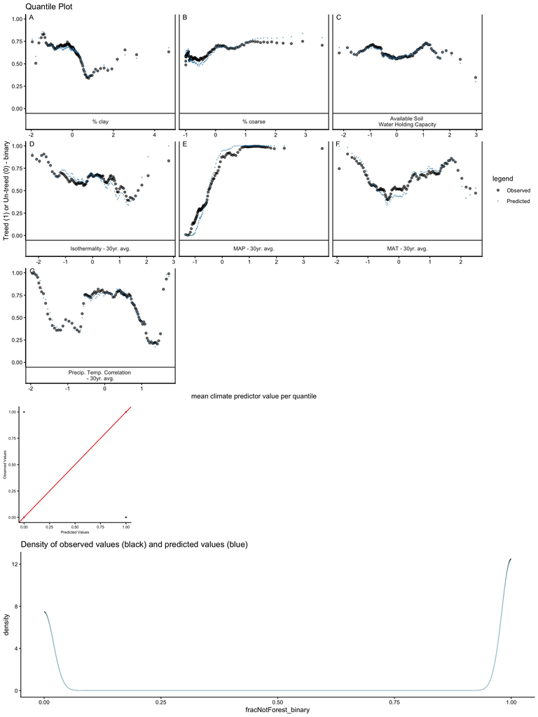

```r
if ( name_secondBestMod == "Intercept_Only") {
  print("The next best lambda model only contains one predictor (an intercept)")
  } else {

# publication quality version
g3 <- decile_dotplot_pq(pred_glm1_deciles_1se, response = c("fracNotForest_binary", paste0("fracNotForest", "_pred_binary")), IQR = FALSE) + ggtitle("Quantile Plot") +
  ggplot2::labs(y = "Treed (1) or Un-treed (0) - binary")

g4 <- add_dotplot_inset(g3, df = pred_glm1_deciles_1se, response = c("fracNotForest_binary", paste0("fracNotForest", "_pred_binary")), dfRaw = pred_glm1_1se_full, add_smooth = TRUE, deciles = FALSE)


if(save_figs) {
  # png(paste0("figures/quantile_plots/quantile_plot_", response,  "_",ecoregion,".png"),
  #    units = "in", res = 600, width = 5.5, height = 3.5 )
  #   print(g4)
  # dev.off()
}

 g4 <- ggarrange(g4, ggplot(pred_glm1_1se_full) +
  geom_density(aes(.data[["fracNotForest_binary"]])) +
  geom_density(aes(.data[["fracNotForest_pred_binary"]]), col = "lightblue") +
    ggtitle("Density of observed values (black) and predicted values (blue)"),
  ncol = 1, heights = c(.75, .25)
 )

 g4

}
```

### Show model RMSE w/in each quantile (RMSE calculated by comparing binary predictions to binary observations)

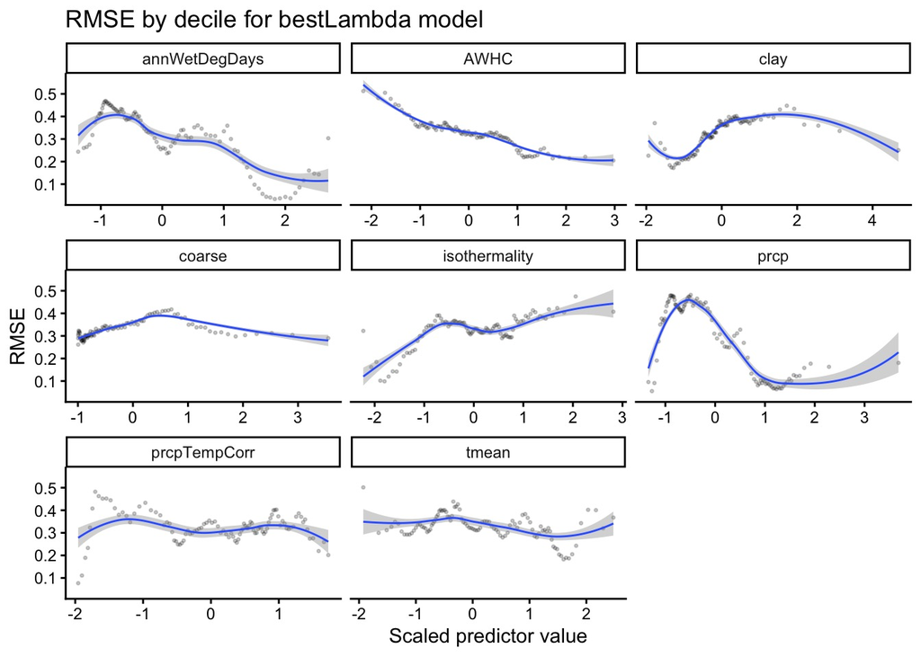

```r
# get deciles for best lambda model
if (length(prednames_fig) == 0) {
  print("The best lambda model only contains one predictor (an intercept), so decile plots aren't possible to generate")
} else {
  pred_glm1_deciles %>%
    ggplot(aes(x = mean_value, y = RMSE)) +
    facet_wrap(~name, scales = "free_x") +
    geom_point(alpha = .2, size = .5) +
    geom_smooth(lwd = .5) +
    xlab("Scaled predictor value") +
    ggtitle("RMSE by decile for bestLambda model")
}
```

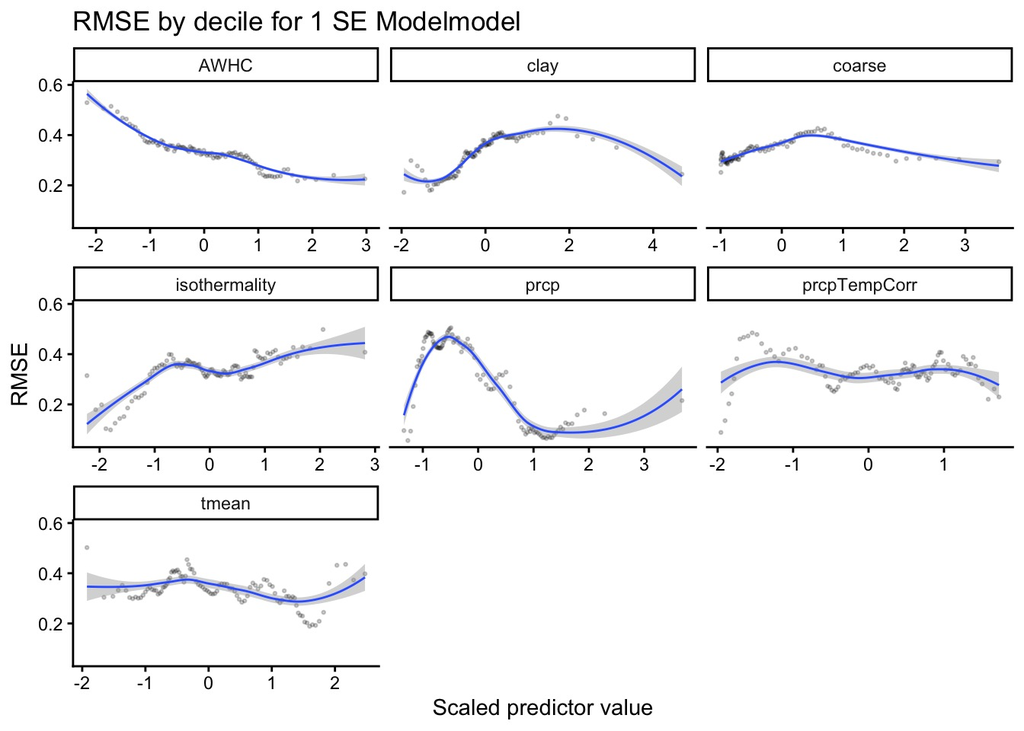

```r
# get deciles for 1 SE lambda model
if (length(prednames_secondBestMod) == 0) {
  print("The 1SE (or 1/2 SE) lambda model only contains one predictor (an intercept), so decile plots aren't possible to generate")
} else {
  pred_glm1_deciles_1se %>%
    ggplot(aes(x = mean_value, y = RMSE)) +
    facet_wrap(~name, scales = "free_x") +
    geom_point(alpha = .2, size = .5) +
    geom_smooth(lwd = .5) +
    xlab("Scaled predictor value") +
    ggtitle(paste0("RMSE by decile for ", name_secondBestMod, "model"))
}
```

### Partial dependence plots (continuous model predictions)

For best lambda

```r
# get names of coefficients in models
predNames_pdp_bestLambda <- names(coefficients(fit_glm_bestLambda)[-1])

## make a 'model.matrix' for the full dataset
X_pdp_bestLambda <- model.matrix(fit_glm_bestLambda$formula, modDat_1_s_FULL) %>%
  as.data.frame()
X_pdp_bestLambda <- X_pdp_bestLambda %>%
  left_join(modDat_1_s_FULL[prednames_fig])
```

[output not shown]

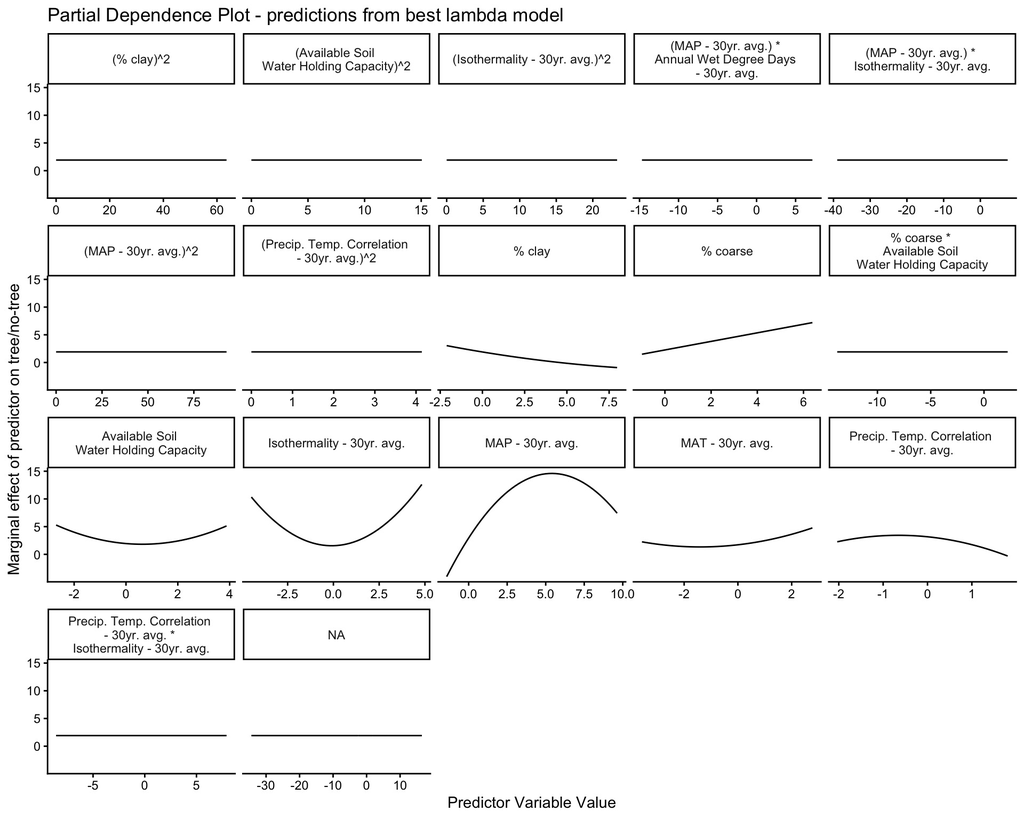

```r
for (i in 1:length(predNames_pdp_bestLambda)) {
  pd_bestLambda_i <- pdp::partial(object = fit_glm_bestLambda, pred.var = predNames_pdp_bestLambda[i], train = X_pdp_bestLambda, type = "regression", )
  names(pd_bestLambda_i)[1] <- "predictorVariable_value"
  pd_bestLambda_i$predictorVariable_Name <- predNames_pdp_bestLambda[i]
  if(i == 1) {
    pd_bestLambda <- pd_bestLambda_i
  } else {
    pd_bestLambda <- rbind(pd_bestLambda, pd_bestLambda_i)
  }
}

## update predictor names to be more interpretable
lookup_md <- c(
    "AWHC" = "Available Soil \nWater Holding Capacity",
    "VPD_mean_anom" = "VPD mean \n- 3 yr. anomaly",
    "VPD_max" = "VPD max - 30yr. avg.",
    "VPD_max_95_anom" = "VPD max 95th percentile \n- 30yr. avg.",
    "VPD_min_anom" = "VPD min - 3 yr. anomaly",
    "aboveFreezingMonth_anom" = "First Above Freezing Month \n- 3 yr. anomaly",
    "annWatDef" = "Ann. Water Deficit \n- 30yr. avg.",
    "annWatDef_anom" = "Ann. Water Deficit \n- 3 yr. anomaly",
    "annWetDegDays_anom" = "Annual Wet Degree Days \n- 3 yr. anomaly",
    "annWetDegDays" = "Annual Wet Degree Days \n- 30yr. avg.",
    "coarse" = "% coarse",
    "clay" = "% clay",
    "frostFreeDays_5_anom" = "No. Frost-Free Days 5th \nPercentile - 3 yr. anomaly",
    "isothermality" = "Isothermality - 30yr. avg.",
    "isothermality_anom" = "Isothermality - 3 yr. anomaly",
    "prcp" = "MAP - 30yr. avg.",
    "prcp_dry" = "Precip. of Driest Month \n- 30yr. avg.",
    "prcpTempCorr" = "Precip. Temp. Correlation \n- 30yr. avg.",
    "prcpTempCorr_anom" = "Precip. Temp. Correlation \n- 3 yr. anomaly",
    "prcp_seasonality" = "Precip. Seasonality \n- 30yr. avg.",
    "prcp_seasonality_anom" = "Precip. Seasonality\n - 3 yr. anomaly",
    "prcp_wet_anom" = "Precip. of Wettest Month \n- 3 yr. anomaly",
    "precp_dry_anom" = "Precip. of Driest Month \n- 3 yr. anomaly",
    "prcp_anom" = "MAP - 3 yr. anomaly",
    "sand" = "% sand",
    "carbon" = "% carbon in soil surface",
    "t_cold_anom" = "Temp. of Coldest Month \n- 3 yr. anomaly",
    "t_warm_anom" = "Temp. of Warmest Month \n- 3 yr. anomaly",
    "tmax_anom" = "Ann. Maximum Temp. \n- 3 yr. anomaly",
    "tmean" = "MAT - 30yr. avg.",
    "tmin_anom" = "Ann. Minimum Temp. \n- 3 yr. anomaly",
    "prcp_wet" = "Precip. of Wettest Month \n- 30yr. avg.",
    "t_warm" = "Temp. of Warmest Month \n- 30yr. avg.",
    "soilDepth" = "Soil Depth",
    "t_cold" = "Temp. of Coldest Month \n- 30yr. avg.",
    "annWatDef_95" = "Ann. Water Deficit 95th \nPercentile - 30yr. avg.",
    # squared terms
    "I(prcp^2)" = "(MAP - 30yr. avg.)^2",
    "I(prcpTempCorr^2)" = "(Precip. Temp. Correlation \n- 30yr. avg.)^2",
    "I(isothermality^2)" = "(Isothermality - 30yr. avg.)^2",
    "I(clay^2)" = "(% clay)^2",
    "I(AWHC^2)" = "(Available Soil \nWater Holding Capacity)^2",
    # interactions
    "prcp:annWetDegDays" = "(MAP - 30yr. avg.) * \nAnnual Wet Degree Days \n- 30yr. avg.",
    "prcp:isothermality" = "(MAP - 30yr. avg.) * \nIsothermality - 30yr. avg.",
    "prcpTempCorr:isothermality" = "Precip. Temp. Correlation \n- 30yr. avg. * \nIsothermality - 30yr. avg.",
    "isothermality:tmean" = " Isothermality - 30yr. avg. * \nMAT - 30yr. avg.",
    "prcpTempCorr:tmean" = "Precip. Temp. Correlation \n- 30yr. avg. * \nMAT - 30yr. avg.",
    "AWHC:clay" = "Available Soil \nWater Holding Capacity * \n% clay",
    "coarse:AWHC" = "% coarse * \nAvailable Soil \nWater Holding Capacity",
    "coarse:clay" =  "% coarse * \nAvailable Soil \n% clay"
  ) %>%
  data.frame()
names(lookup_md) <- c("longName")
lookup_md$predName <- rownames(lookup_md)

pd_bestLambda <- pd_bestLambda %>%
  left_join(lookup_md, by = c("predictorVariable_Name" = "predName"))

ggplot(pd_bestLambda) +
  facet_wrap(~longName,scales = "free_x") +
  geom_line(aes(x = predictorVariable_value, y = yhat)) +
  labs(title = "Partial Dependence Plot - predictions from best lambda model",
          x = "Predictor Variable Value",
          y = paste0("Marginal effect of predictor on tree/no-tree"))
```

For Second-best lambda plot

[output not shown]

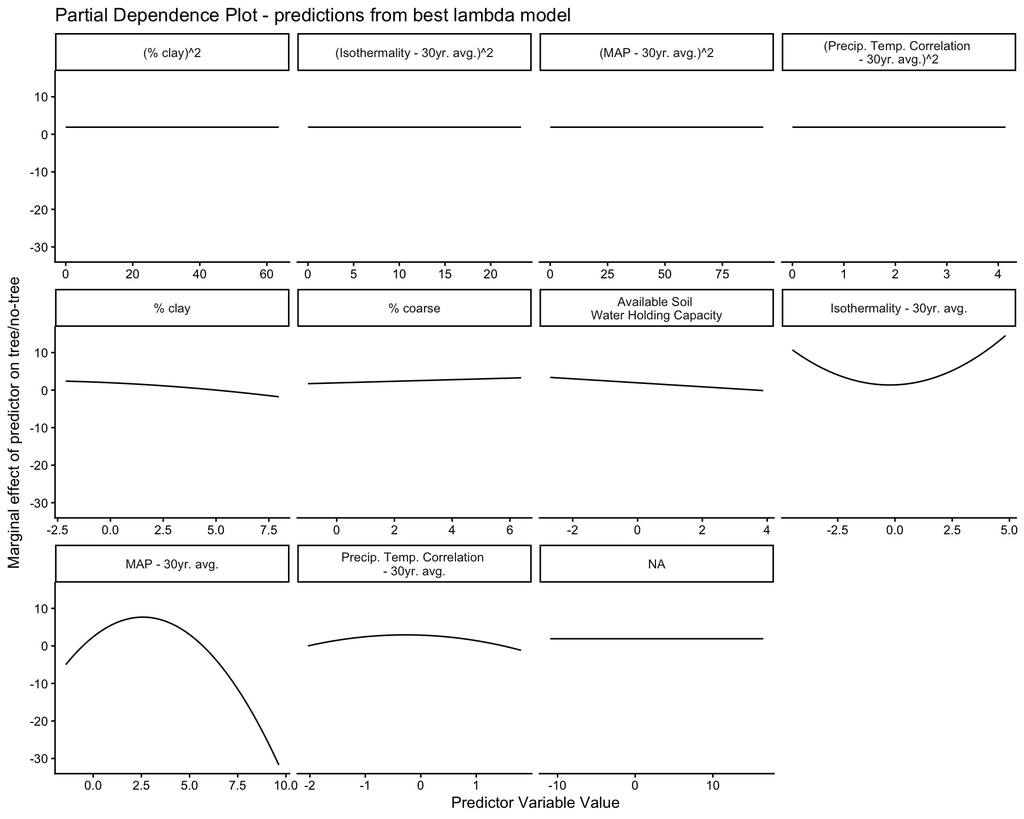

```r
if ( name_secondBestMod == "Intercept_Only") {
  print("The next best lambda model only contains one predictor (an intercept), so partial dependence plots are impractical")
  } else {# get names of coefficients in models
predNames_pdp_secondBestLambda <- names(coefficients(mod_secondBest)[-1])

## make a 'model.matrix' for the full dataset
X_pdp_secondBestLambda <- model.matrix(mod_secondBest$formula, modDat_1_s_FULL) %>%
  as.data.frame()
X_pdp_secondBestLambda <- X_pdp_secondBestLambda %>%
  left_join(modDat_1_s_FULL[prednames_secondBestMod])

for (i in 1:length(predNames_pdp_secondBestLambda)) {
  pd_secondBestLambda_i <- pdp::partial(object = mod_secondBest, pred.var = predNames_pdp_secondBestLambda[i], train = X_pdp_secondBestLambda, type = "regression", )
  names(pd_secondBestLambda_i)[1] <- "predictorVariable_value"
  pd_secondBestLambda_i$predictorVariable_Name <- predNames_pdp_secondBestLambda[i]
  if(i == 1) {
    pd_secondBestLambda <- pd_secondBestLambda_i
  } else {
    pd_secondBestLambda <- rbind(pd_secondBestLambda, pd_secondBestLambda_i)
  }
}

## update predictor names to be more interpretable
lookup_md <- c(
    "AWHC" = "Available Soil \nWater Holding Capacity",
    "VPD_mean_anom" = "VPD mean \n- 3 yr. anomaly",
    "VPD_max" = "VPD max - 30yr. avg.",
    "VPD_max_95_anom" = "VPD max 95th percentile \n- 30yr. avg.",
    "VPD_min_anom" = "VPD min - 3 yr. anomaly",
    "aboveFreezingMonth_anom" = "First Above Freezing Month \n- 3 yr. anomaly",
    "annWatDef" = "Ann. Water Deficit \n- 30yr. avg.",
    "annWatDef_anom" = "Ann. Water Deficit \n- 3 yr. anomaly",
    "annWetDegDays_anom" = "Annual Wet Degree Days \n- 3 yr. anomaly",
    "annWetDegDays" = "Annual Wet Degree Days \n- 30yr. avg.",
    "coarse" = "% coarse",
    "clay" = "% clay",
    "frostFreeDays_5_anom" = "No. Frost-Free Days 5th \nPercentile - 3 yr. anomaly",
    "isothermality" = "Isothermality - 30yr. avg.",
    "isothermality_anom" = "Isothermality - 3 yr. anomaly",
    "prcp" = "MAP - 30yr. avg.",
    "prcp_dry" = "Precip. of Driest Month \n- 30yr. avg.",
    "prcpTempCorr" = "Precip. Temp. Correlation \n- 30yr. avg.",
    "prcpTempCorr_anom" = "Precip. Temp. Correlation \n- 3 yr. anomaly",
    "prcp_seasonality" = "Precip. Seasonality \n- 30yr. avg.",
    "prcp_seasonality_anom" = "Precip. Seasonality\n - 3 yr. anomaly",
    "prcp_wet_anom" = "Precip. of Wettest Month \n- 3 yr. anomaly",
    "precp_dry_anom" = "Precip. of Driest Month \n- 3 yr. anomaly",
    "prcp_anom" = "MAP - 3 yr. anomaly",
    "sand" = "% sand",
    "carbon" = "% carbon in soil surface",
    "t_cold_anom" = "Temp. of Coldest Month \n- 3 yr. anomaly",
    "t_warm_anom" = "Temp. of Warmest Month \n- 3 yr. anomaly",
    "tmax_anom" = "Ann. Maximum Temp. \n- 3 yr. anomaly",
    "tmean" = "MAT - 30yr. avg.",
    "tmin_anom" = "Ann. Minimum Temp. \n- 3 yr. anomaly",
    "prcp_wet" = "Precip. of Wettest Month \n- 30yr. avg.",
    "t_warm" = "Temp. of Warmest Month \n- 30yr. avg.",
    "soilDepth" = "Soil Depth",
    "t_cold" = "Temp. of Coldest Month \n- 30yr. avg.",
    "annWatDef_95" = "Ann. Water Deficit 95th \nPercentile - 30yr. avg.",
    # squared terms
    "I(prcp^2)" = "(MAP - 30yr. avg.)^2",
    "I(prcpTempCorr^2)" = "(Precip. Temp. Correlation \n- 30yr. avg.)^2",
    "I(isothermality^2)" = "(Isothermality - 30yr. avg.)^2",
    "I(clay^2)" = "(% clay)^2",
    "I(AWHC^2)" = "(Available Soil \nWater Holding Capacity)^2",
    # interactions
    "prcp:annWetDegDays" = "(MAP - 30yr. avg.) * \nAnnual Wet Degree Days \n- 30yr. avg.",
    "prcp:isothermality" = "(MAP - 30yr. avg.) * \nIsothermality - 30yr. avg.",
    "prcpTempCorr:isothermality" = "Precip. Temp. Correlation \n- 30yr. avg. * \nIsothermality - 30yr. avg.",
    "isothermality:tmean" = " Isothermality - 30yr. avg. * \nMAT - 30yr. avg.",
    "prcpTempCorr:tmean" = "Precip. Temp. Correlation \n- 30yr. avg. * \nMAT - 30yr. avg.",
    "AWHC:clay" = "Available Soil \nWater Holding Capacity * \n% clay",
    "coarse:AWHC" = "% coarse * \nAvailable Soil \nWater Holding Capacity",
    "coarse:clay" =  "% coarse * \nAvailable Soil \n% clay"
  ) %>%
  data.frame()
names(lookup_md) <- c("longName")
lookup_md$predName <- rownames(lookup_md)

pd_secondBestLambda <- pd_secondBestLambda %>%
  left_join(lookup_md, by = c("predictorVariable_Name" = "predName"))

ggplot(pd_secondBestLambda) +
  facet_wrap(~longName,scales = "free_x") +
  geom_line(aes(x = predictorVariable_value, y = yhat)) +
  labs(title = "Partial Dependence Plot - predictions from best lambda model",
          x = "Predictor Variable Value",
          y = paste0("Marginal effect of predictor on tree/no-tree"))
}
```

```r
# function for printing model statement
## function to get model statements
getModelStatement <- function(coefficientTable, # name of the d.f that has model coefficients
                  modelName, # name of the column in the coefficient table that has the parameters of interest
                  responseVar # name of the response variable
                  ) {
  ##
  # coefficientTable <- grassShrub_totalHerb_trimAnoms
  # modelName <- "coefficientValue_bestLambda"
  # responseVar <- "TotalHerbaceousCover"
  ##
  temp <- coefficientTable[,c("coefficientName", modelName)] %>%
    drop_na()
  rownames(temp) <- temp$coefficientName
  temp[,modelName] <- round(temp[,modelName], 8)

  # print out coefficients w/ coefficient names
tempNames <- paste0(
  apply(temp, MARGIN = 1, FUN = function(x) {
    if (x["coefficientName"] == "(Intercept)") {
      paste0(x[modelName])
    } else {
      paste0(x[modelName], "*", x["coefficientName"])
    }
    }
  ),
  collapse = " + "
)

# print the unscaled model statement
  unscaledModelName <- paste0(responseVar, "~ 1/(1 + exp(-(", tempNames, ")))")

## print scaled model statement

return(list("scaledInputVars_ModelStatement" = unscaledModelName))
}


## bestLambda model equations
bestLambdaModStatement <- getModelStatement(coefficientTable = coefs,
                  modelName = "coefficientValue_bestLambda",
                  responseVar = "P(Tree)")
## second-best lambda model equations
secondBestLambdaModStatement <- getModelStatement(coefficientTable = coefs,
                  modelName = ifelse(name_secondBestMod == "1/2 SE Model",
                                      yes = "coefficientValue_halfseLambda",
                                     no = "coefficientValue_1seLambda"),
                  responseVar = "P(Tree)")
```

#### The equation for the bestLambda model if the inputs *are* scaled is:

```r
print(bestLambdaModStatement$scaledInputVars_ModelStatement)
```

[output not shown]

#### The equation for the *second*-bestLambda model if the inputs *are* scaled is:

```r
print(secondBestLambdaModStatement$scaledInputVars_ModelStatement)
```

[output not shown]